# Demo BKWD Selection and HMM

Kehinde Fagbamigbe

2023-07-04

### Install Required packages

```r
install.packages("/Users/alhajidot/Documents/BGSU/Project/Model Fitting/new package/package/matrixNormal_0.0.1.tar.gz", type = "source", repos = NULL)

install.packages("/Users/alhajidot/Documents/BGSU/Project/Model Fitting/new package/package/mhsmm2_0.4.17.tar.gz", type = "source", repos = NULL)
```

### Load required Libraries

```r
rm(list = ls())
library(dplyr)
library(tidyverse)
library(grid)
library(gridExtra)
library(mvtnorm)
library(mhsmm2)
library(ks)
library(matrixNormal)
library(MixSim)
library(mclust)
```

## Data Gathering

### Race Acronyms and meanings

- EFAIAN –> American Indian or Alaska Native
- EFBKAA –> Black or African American
- EFHISP –> Hispanic
- EFWHIT –> White
- EFUNKN –> Race/ethnicity unknown
- EFNRAL –> Nonresident alien
- EFASIAM + EFNHPIM DVEFAIM / EFNHPI –> Native Hawaiian or Other Pacific Islander

### CIPCODE Majors/Section

- 26 Biological Sciences/Life Sciences
- 27 Mathematics
- 40 Physical Sciences
- 52 Business Management and Administrative Services

### Line

- 8 Total full-time undergraduates
- 22 Total part-time undergraduates

### Section

- 1 Full-time
- 2 Part-time

### Level Of Study

- 1 All students total
- 2 All students, Undergraduate total

```r
#path <- "/Users/alhajidot/Documents/BGSU/Project/UG_data/"
path <- "/Users/alhajidot/Documents/BGSU/Project/new_structured_undergrad/"

# Find all the files in the directory that match the pattern "[0-9][0-9][0-9][0-9].csv" e.g 1994.csv , 1995.csv e.t.c
files <- list.files(path, pattern = "[0-9][0-9][0-9][0-9].csv")

# Determine the number of files that match the pattern
num_files <- length(files)

# Print the result
print(num_files)
```

```
## [1] 14
```

### Using files to create start and end

```r
files <- as.list(files)
```

```r
start <- files[[1]]
start <- as.numeric(substr(start, 1, 4))
start
```

```
## [1] 1994
```

```r
end <- files[[length(files)]]
end <- as.numeric(substr(end, 1, 4))
end
```

```
## [1] 2020
```

#### Read Data

```r
major <- c(13, 14, 26, 27, 40, 52) # 13: Education, 14: Engineering, 26: BioSc, 27: Math, 40: PhySc, 52: Business
race.male <-  c("EFAIANM", "DVEFAIM", "EFBKAAM", "EFHISPM", "EFWHITM", "EFUNKNM", "EFNRALM")
race.female <-  c("EFAIANW", "DVEFAIW", "EFBKAAW", "EFHISPW", "EFWHITW", "EFUNKNW", "EFNRALW")
p <- length(major)
q <- length(race.male)
T <-  num_files   #14 change this count as datasets increases
```

### Notations and representations

- Y[i,2,j,k,t]
- #i, no of records/institution
- #j/p Majors
- #k/q: Race
- #t/T Year

### Getting the unique number of universities across all the years

```r
all.school.id <- list() #creates an empty list

for (t in 1:T){
  yr <- start + 2*(t-1)

  df1 <- read.csv(paste(path, yr, ".csv", sep=""), header=TRUE)
  all.school.id[[t]] <- unique(df1$UNITID) #gets all the unique code of faculty in each document i.e each year
}

common.school.id <- intersect(all.school.id[[1]], all.school.id[[2]]) ##compares the id in the first and second year data i.e 1994 and 1996

for (t in 3:T){
  common.school.id <- intersect(common.school.id, all.school.id[[t]]) #only get the id in all the year documents
}

school.id <- unique(common.school.id)  #gets a unique id found in all the data for all years
n <- length(school.id) #crosscheck the number of unique ids
n
```

```
## [1] 970
```

### creating the male and female arrays

```r
Male <- array(NA, dim = c(n,p,q,T))
Female <- array(NA, dim = c(n,p,q,T))
Y <- array(NA, dim = c(n,p,q,T))

state_info <- read.csv(paste("~/Documents/BGSU/Project/hd2019.csv"), header=TRUE)
state_info <- state_info[,c(1,6)]

#read in just the 1st and the 6th columns of this dataset UNITID where data is found for merged schools, STABBR - State Abbreviation


school.id1 <- cbind(school.id, 1) #just created a column of school Id and a column filled with 1s so it can be good for joining
colnames(school.id1) <- c("UNITID", "none") ##none was created as a dummy column of value to achieve joining
```

### Joining the data

```r
state_info_common <- merge(school.id1, state_info, by.x = "UNITID", by.y = "UNITID", all.x = TRUE, all.y = FALSE) # creating a left join on UNITID
state_info_common[1:4,]
```

```
##   UNITID none STABBR
## 1 100663    1     AL
## 2 100706    1     AL
## 3 100724    1     AL
## 4 100751    1     AL
```

```r
state_info_common <- state_info_common[,-2] #removes second column
state_info_common[1:4,]
```

```
##   UNITID STABBR
## 1 100663     AL
## 2 100706     AL
## 3 100724     AL
## 4 100751     AL
```

### Saving the IDs and State of the schools

```r
save(state_info_common, file = "/Users/alhajidot/Documents/BGSU/Project/Model Fitting/Project Rcode/Rdata files/state_info_common.Rdata")
#this saves the R workspace, including all variables and their values, to a file in binary format. and load("workspace.RData") will be used to load the data
```

### creating a list of all the required columns

```r
search_list <- c("UNITID", "CIPCODE", "DVEFAIW","DVEFAIM", "EFAIANW", "EFBKAAW", "EFHISPW", "EFWHITW", "EFUNKNW", "EFNRALW", "EFAIANM", "EFBKAAM", "EFHISPM", "EFWHITM", "EFUNKNM", "EFNRALM") #"DVEFAIW"  and DVEFAIM have been coded in another way EFNHPIM + EFASIAM and EFNHPIW  + EFASIAW respectively in the data
search_list
```

```
##  [1] "UNITID"  "CIPCODE" "DVEFAIW" "DVEFAIM" "EFAIANW" "EFBKAAW" "EFHISPW"
##  [8] "EFWHITW" "EFUNKNW" "EFNRALW" "EFAIANM" "EFBKAAM" "EFHISPM" "EFWHITM"
## [15] "EFUNKNM" "EFNRALM"
```

### Esuring all data are in the same structure

```r
### group data from 1994 to 2000 by UNITID and CIPCODE
for (t in 1:4){ #1994 - 2000 only contains th section column which is the third column
  yr <- 1994 + 2*(t-1)
  df1 <- read.csv(paste(path, yr, ".csv", sep=""), header=TRUE)
  #df1 <- df1[,-3] #removes the third column called section
  df2 <- df1 %>%
    group_by(UNITID,    CIPCODE) %>%
    dplyr::summarise(across(everything(), sum)) # is this supposed to be sum or count...this totally depends on the definition of the columns.


for (i in 1:n){
    schl_data.m <- as.data.frame(df2[which(df2$UNITID == school.id[i]),c("UNITID", "CIPCODE", race.male)]) #which gets the index and it is used to get the specified column names, this is done for both male and female
    schl_data.f <- as.data.frame(df2[which(df2$UNITID == school.id[i]),c("UNITID", "CIPCODE",race.female)])
    for (j in 1:dim(schl_data.m)[1]){ #done since we do not get to know the no of rows of the data generated by just the male
      if (sum(match(major,schl_data.m$CIPCODE[j], nomatch=0)) > 0){ #it returns a 0 if there is no match. #it checks to match the majors we specified at the beginning
        major.index = which(match(major,schl_data.m$CIPCODE[j]) == TRUE)
        for (k in 1:q){ #q is the length of all the male column
          Male[i,major.index,k,t] <- schl_data.m[j,2+k] #Male is the 4 dimensional array created earlier
          Female[i,major.index,k,t] <- schl_data.f[j,2+k] #Female is the 4 dimensional array created earlier
        }
      }
    }
  }
}
## we have unique UNITID,   CIPCODE so no need to group data from year 2002 till date (2022)

for (t in 5:num_files){
  yr <- 1994 + 2*(t-1)
  df2 <- read.csv(paste(path, yr, ".csv", sep=""), header=TRUE)

  for (i in 1:n){ #n is: n <- length(school.id)
    schl_data.m <- as.data.frame(df2[which(df2$UNITID == school.id[i]),c("UNITID", "CIPCODE",race.male)])
    schl_data.f <- as.data.frame(df2[which(df2$UNITID == school.id[i]),c("UNITID", "CIPCODE",race.female)])
    for (j in 1:dim(schl_data.m)[1]){
      if (sum(match(major,schl_data.m$CIPCODE[j], nomatch=0)) > 0){
        major.index = which(match(major,schl_data.m$CIPCODE[j]) == TRUE)
        for (k in 1:q){
          Male[i,major.index,k,t] <- schl_data.m[j,2+k]
          Female[i,major.index,k,t] <- schl_data.f[j,2+k]
        }
      }
    }
  }
}
```

```r
## Combine "American Indian or Alaska Native" and "Asian /Native Hawaiian or Other Pacific Islander" i.e EFAIANM + DVEFAIM
## Drop Race/ethnicity unknown i.e drop/ do not include EFUNKNM
## Drop Engineering because more 50% time it is missing for all racial categories for all years
## Drop Education because many colleges didn't have it in initial years

#major <- c(13, 14, 26, 27, 40, 52) # 13: Education, 14: Engineering, 26: BioSc, 27: Math, 40: PhySc, 52: Business
# race.male <-  c("EFAIANM", "DVEFAIM", "EFBKAAM", "EFHISPM", "EFWHITM", "EFUNKNM", "EFNRALM")
# race.female <-  c("EFAIANW", "DVEFAIW", "EFBKAAW", "EFHISPW", "EFWHITW", "EFUNKNW", "EFNRALW")
# p <- length(major)
# q <- length(race.male)

Male.old <- Male
Female.old <- Female
p <- 4 # 26: BioSc, 27: Math, 40: PhySc, 52: Business
q <- 5 # "EFAIANM"+"DVEFAIM", "EFBKAAM", "EFHISPM", "EFWHITM", "EFNRALM"


Male <- array(NA, dim = c(n,p,q,T))
Female <- array(NA, dim = c(n,p,q,T))
Y <- array(NA, dim = c(n,2,p,q,T)) #why 2? ans: because we have both male and female



for (i in 1:n){
  for (j in 1:p){
    for (k in 1:q){
      for (t in 1:T){
        if (k == 1){

          Male[i,j,k,t] <- Male.old[i,j+2,k,t] + Male.old[i,j+2,k+1,t]  #j+2 means we are ignoring 13 Education and 14 Engineering
          #if k = 1 means add EFAIANM (first column) and DVEFAIM (second column)
          Female[i,j,k,t] <- Female.old[i,j+2,k,t] + Female.old[i,j+2,k+1,t]

        }else if (k == 5){

          Male[i,j,k,t] <- Male.old[i,j+2,k+2,t] #needed because the race is EFAIANM, DVEFAIM, EFBKAAM, EFHISPM, EFWHITM, EFUNKNM, and EFNRALM So for k = 5 it needs to skip 6(EFUNKNM) and include the 7th(EFNRALM)
          Female[i,j,k,t] <- Female.old[i,j+2,k+2,t]

        }else{
          Male[i,j,k,t] <- Male.old[i,j+2,k+1,t] # this just takes 26 Biosc, 27 Math, 40 PhySc, 52 Business then  DVEFAIM, EFBKAAM, EFHISPM, and EFWHITM.
          Female[i,j,k,t] <- Female.old[i,j+2,k+1,t]
        }
      }
    }
  }
}



for (i in 1:n){
  for (j in 1:p){
    for (k in 1:q){
      for (t in 1:T){
        Y[i,1,j,k,t] <- Female[i,j,k,t]
        Y[i,2,j,k,t] <- Male[i,j,k,t]
      }
    }
  }
}



p <- 4 # 26: BioSc, 27: Math, 40: PhySc, 52: Business
q <- 5 # "EFAIANM"+"DVEFAIM", "EFBKAAM", "EFHISPM", "EFWHITM", "EFNRALM"

save(Y, file = "/Users/alhajidot/Documents/BGSU/Project/Model Fitting/Project Rcode/Rdata files/Y.Rdata")
```

### Data Preparation

```r
load("/Users/alhajidot/Documents/BGSU/Project/Model Fitting/Project Rcode/Rdata files/Y.Rdata")
data1 = Y
dim(data1)
```

```
## [1] 970   2   4   5  14
```

### Checking index having missing values

```r
index <- NULL


for ( i in 1:dim(data1)[1]){

  index[i] <- sum(is.na(data1[i,,,,]))

}
index.2 <- which(index > 0 )
index.2  # These are index with missing values
```

```
##   [1]  10  11  14  18  19  21  24  25  27  28  30  31  37  38  41  42  45  46
##  [19]  64  65  70  71  72  73  76  78  79  80  81  90  92  94  95 100 101 103
##  [37] 111 112 114 120 121 123 125 126 127 129 131 132 138 139 140 141 143 151
##  [55] 152 154 156 158 159 161 165 166 168 173 176 177 178 180 183 186 189 190
##  [73] 193 194 198 201 206 209 211 214 217 218 220 222 226 227 228 231 234 236
##  [91] 238 241 247 249 250 251 252 254 255 259 260 263 264 269 271 272 275 289
## [109] 290 291 293 295 296 297 298 299 305 310 312 314 315 317 318 319 320 321
## [127] 322 323 325 326 327 328 331 332 335 337 338 341 342 344 345 347 350 354
## [145] 357 358 361 362 367 372 374 375 378 381 386 393 394 399 403 404 405 406
## [163] 407 408 409 412 416 417 423 427 429 432 433 434 436 437 439 441 445 446
## [181] 447 449 452 453 457 458 459 461 462 470 471 481 489 491 493 494 495 496
## [199] 498 501 503 504 505 506 508 509 511 515 517 521 522 523 527 528 530 531
## [217] 533 535 538 539 540 544 545 546 547 552 568 569 571 573 576 579 580 589
## [235] 590 591 592 593 594 598 601 605 606 607 608 610 611 612 613 615 616 617
## [253] 619 620 622 625 627 629 630 633 641 642 643 649 651 654 655 656 659 661
## [271] 663 665 667 668 670 671 680 682 683 684 685 690 692 699 703 707 708 713
## [289] 714 715 723 726 729 731 734 735 737 738 742 743 747 759 761 763 765 768
## [307] 770 772 773 774 775 776 777 779 782 787 790 791 798 802 804 805 807 812
## [325] 813 815 816 823 829 847 850 851 852 856 857 860 862 865 867 869 872 874
## [343] 878 879 883 884 888 894 895 904 905 907 909 911 914 915 918 921 924 925
## [361] 926 927 928 929 937 940 948 949 950 951 952 953 954 955 956 957 958 959
## [379] 960 961 962 963 965 966 968 969 970
```

#### Removing index having missing values

```r
data2 <- data1[-c(index.2),,,,]

dim(data2) ##data2 has no missing values
```

```
## [1] 583   2   4   5  14
```

### Reading School IDs and State Abbreviations and removing IDS having missing values

```r
load("/Users/alhajidot/Documents/BGSU/Project/Model Fitting/Project Rcode/Rdata files/state_info_common.Rdata")
state_info <- state_info_common[-index.2 , ]
dim(state_info)
```

```
## [1] 583   2
```

### Checking the length of schools in Ohio without missing values

```r
index.OH <- which(state_info$STABBR=="OH")

length(index.OH)
```

```
## [1] 22
```

```r
data.OH <- data2[index.OH,,,,] #data.OH has OH data without any missing values

dim(data.OH)
```

```
## [1] 22  2  4  5 14
```

```r
data.new <- array(NA, dim = c(dim(data.OH)[1], dim(data.OH)[2], dim(data.OH)[3], dim(data.OH)[5]))

for ( i in 1:dim(data.OH)[1]){ ## 1:22
  for (j in 1:dim(data.OH)[5]){ ## 1:14
    for ( g in 1:dim(data.OH)[2]){ ## 1:2
        data.new[i,g,1:4,j] <- rowSums(data.OH[i,g,,,j]) ## aggregating over race
    }
  }
}

dim(data.new)
```

```
## [1] 22  2  4 14
```

#### checking to confirm the aggregation on race works as intended

```r
data.new[12,,,3]
```

```
##      [,1] [,2] [,3] [,4]
## [1,]    7   10    3  169
## [2,]    3    3    2  159
```

#### Original data with race dimension

```r
data.OH[12,,,,3]
```

```
## , , 1
##
##      [,1] [,2] [,3] [,4]
## [1,]    0    0    0    0
## [2,]    0    0    0    0
##
## , , 2
##
##      [,1] [,2] [,3] [,4]
## [1,]    0    0    0   24
## [2,]    0    0    0   16
##
## , , 3
##
##      [,1] [,2] [,3] [,4]
## [1,]    0    0    0    2
## [2,]    0    0    0    0
##
## , , 4
##
##      [,1] [,2] [,3] [,4]
## [1,]    7   10    3  143
## [2,]    3    3    2  142
##
## , , 5
##
##      [,1] [,2] [,3] [,4]
## [1,]    0    0    0    0
## [2,]    0    0    0    1
```

```r
dim(data.new)
```

```
## [1] 22  2  4 14
```

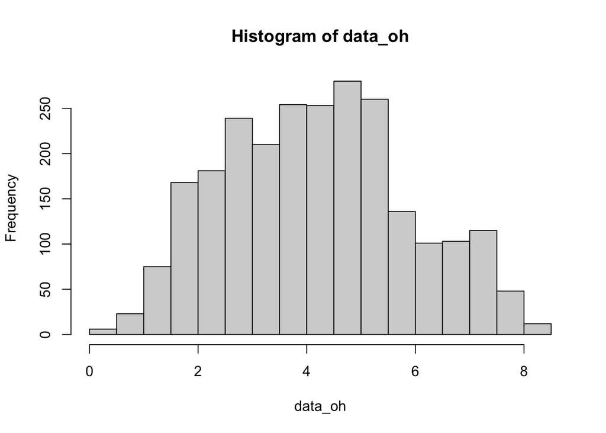

```r
data_oh <- log(data.new+1) # why are we adding 1?
hist(data_oh)
```

## Model Fitting

fitting a hidden Markov model (HMM) with a mixture of multivariate normal distributions as the emission distribution. The input data is in the form of a 4-dimensional array called data_oh, with dimensions 22 x 2 x 4 x 14.

### All Possible Combinations

```r
data_al <- data_oh
dim(data_al)
```

```
## [1] 22  2  4 14
```

```r
model <- readRDS("model_non.rds") # model returned from the unrestricted run
```

## function to calculate the parameters when initializing the algorithm

### for the restricted case.

```r
set.seed(1)


mstep.rest22 <- function (Data, model, ind.matrix)  {

  x <- Data

  wt <- model$gam

  ind.mat <- ind.matrix


  Sigma = model$model$parms.emission$sigma
  Psi = model$model$parms.emission$psi

  n <- dim(x)[1]
  p <- dim(x)[2]
  d <- dim(x)[3]
  T <- dim(x)[4]
  K <- dim(wt)[2]

  Means = Means.eq= Means.non= BB= Sigmas = Psis <- vector("list", ncol(wt))

  for (k in 1:K) {
    Means[[k]] <- matrix(0, nrow = p, ncol = d)
    Means.eq[[k]] <- matrix(0, nrow = p, ncol = d)
    Means.non[[k]] <- matrix(0, nrow = p, ncol = d)
    BB[[k]] <- matrix(0, nrow = 1, ncol = d)
    Sigmas[[k]] <- matrix(0, nrow = p, ncol = p)
    Psis[[k]] <- matrix(0, nrow = d, ncol = d)
  }

  A <- matrix(1, nrow = 2)

  for (i in 1:n) {
    for (t in 1:T) {
      for (k in 1:K) {
        BB[[k]] <- BB[[k]] + wt[i, k, t] * solve(t(A) %*% solve(Sigma[[k]]) %*% A) %*% (t(A)%*%solve(Sigma[[k]])%*% x[i, , , t])    / sum(wt[, k, ])
      }
    }
  }

  for ( k in 1:K){
    Means.eq[[k]] <- A%*%BB[[k]]
  }


  for (i in 1:n) {
    for (t in 1:T) {
      for (k in 1:K) {
        Means.non[[k]] <- Means.non[[k]] + wt[i, k, t] * x[i, , , t] / sum(wt[, k, ])
      }
    }
  }

  for ( k in 1:K){

    if (all(ind.mat[,k]==0)){
      Means[[k]] <- Means.non[[k]]
    } else  {

      MM <- Means.non[[k]]
      ind.k <- which(ind.mat[,k]==1)
      #print(ind.k)

      for ( m in ind.k){
        MM[,m]<- Means.eq[[k]][,m]
        Means[[k]]<- MM

      }

    }

  }

  for (i in 1:n) {
    for (t in 1:T) {
      for (k in 1:K) {
        Sigmas[[k]] <- Sigmas[[k]] + wt[i, k, t] * matrix(x[i,
                                                            , , t] - Means[[k]], p, d) %*% solve(Psi[[k]]) %*%
          t(matrix(x[i, , , t] - Means[[k]], p, d))/d/sum(wt[,
                                                             k, ])
      }
    }
  }




  for (i in 1:dim(wt)[1]) {
    for (t in 1:dim(wt)[3]) {
      for (k in 1:dim(wt)[2]) {
        Psis[[k]] <- Psis[[k]] + wt[i, k, t] * t(matrix(x[i,
                                                          , , t] - Means[[k]], p, d)) %*% solve(Sigmas[[k]]) %*%
          matrix(x[i, , , t] - Means[[k]], p, d)/p/sum(wt[,
                                                          k, ])
      }
    }
  }


  emission <- list(mu = Means, sigma = Sigmas, psi = Psis)
  return(emission)
}
```

### Unrestricted Case

```r
### runs unrestricted case
search.R <- function(Data, R){

  Data <- Data

  R    <- R


  n <- dim(Data)[1]
  T <- dim(Data)[4]
  p <- dim(Data)[2]
  d <- dim(Data)[3]



  BIC.MN <- rep(NA, R-1) # search starts from 2

  model.cont <- list() # save the models for each r in R

  #### run unrestricted case ##########################

  for ( k in 2:R){


    psi.list   <- list()
    sigma.list <- list()
    S.list     <- list()
    init.list  <- list()
    P.list     <- list()
    Mean.list  <- list()


    # number of parameters for MN
    # Calculate the number of parameters in the model
    no.mn <- k*p*d + k*p*(p+1)/2 +  k*d*(d+1)/2 + k*(k-1) + k-1 -k

    record <- rep(NA, 10*k)

    hh.fit <- list()


    for (j in 1:(10*k)){

      a <- 1:k

      ab <- sample(a, n*T, replace = T)

      #initial <- rep(0, k)
      initial <- rep(1/k, k)
      #initial[ab[1]] <- 1
      init.list[[j]] <- initial

      count <- matrix(0, k, k)
      for(jj in 1:(n-1)){
        count[ab[jj], ab[jj+1]] <- count[ab[jj], ab[jj+1]] +1
      }

      P.list[[j]]<- count/ rowSums(count)

      xse <- list()

      mu.list <- list()
      psi.init<- list()
      sigma.init <- list()

      mu.mat <- array(0, dim = c(p, d, k))

      for (l in 1:k){
        ab.mat <- matrix(ab, n, T)
        init.cov <- NULL
        init.cov2 <- NULL
        for(i in 1:n){
          for(t in 1:T){
            if(ab.mat[i,t] == l){

              mu.mat[,,l] <- mu.mat[,,l] + Data[i,,,t]
              init.cov <- cbind(init.cov, Data[i,,,t])
              init.cov2 <- cbind(init.cov2, t(Data[i,,,t]))
            }
          }
        }
        sigma.init[[l]]<- cov(t(init.cov))
        psi.init[[l]]<- cov(t(init.cov2))
      }
      for (l in 1:k){
        mu.mat[,,l] <- mu.mat[,,l] / sum(ab.mat == l)
        mu.list[[l]] <- mu.mat[,,l]
      }

      Mean.list[[j]] <- mu.list

      psi.list[[j]]<- psi.init

      sigma.list[[j]] <- sigma.init



      pars.mn <- list(mu=Mean.list[[j]], sigma=sigma.list[[j]], psi=psi.list[[j]])



      model.2 <- hmmspec(init=init.list[[j]], trans=P.list[[j]],
                         parms.emission=pars.mn, dens.emission=dmatnorm.hsmm)



      try1<- try(hh.fit[[j]]<- hmmfit(Data,model.2, mstep=mstep.rest, ind.matrix = NULL,
                                      Psi=psi.list[[j]], Sigma= sigma.list[[j]]))

      cat("j", j, "k", k, "\n")

      try2<- try(record[j] <- max(hh.fit[[j]]$loglik))


    }

    ind.log <- which.max(record)

    #saveRDS(hh.fit[[ind.log]], sprintf("modelMN_%s.rds", k))

    model.cont[[k-1]] <-   hh.fit[[ind.log]]



    BIC.MN[k-1] <-  -2*max(hh.fit[[ind.log]]$loglik)+no.mn*log(n*T)


  }


  ind.MN <- which.min(BIC.MN)

  final.model <- model.cont[[ind.MN]]


  BIC.final <- BIC.MN[ind.MN]




  return(list(models = model.cont, BIC.unrest= BIC.MN, final.model = final.model, BIC.final= BIC.final ))


}
```

### Restricted Case

```r
### runs restricted case
## there was a slight decrease in the log-likelihood with this version

test_R1 <- function(Data = Data, model, ind.matrix) {


  aa = mstep.rest22(Data = Data, model = model, ind.matrix = ind.matrix)

  pars <- aa

  k <- dim(ind.matrix)[2]

  p <- 2

  d <- 4

  n <- dim(Data)[1]
  T <- dim(Data)[4]

  # number of parameters for MN
  # Calculate the number of parameters in the model
  no.mn <- k*p*d + k*p*(p+1)/2 +  k*d*(d+1)/2 + k*(k-1) + k-1 -k



  pars.mn <- list(mu=pars$mu, sigma=pars$sigma, psi=pars$psi)



  model.2 <- hmmspec(init=model$model$init, trans =  model$model$transition,
                     parms.emission=pars.mn, dens.emission=dmatnorm.hsmm)



  try1<- try(hh.fit<- hmmfit(Data,model.2, mstep=mstep.rest,
                             Psi=pars$psi, Sigma= pars$sigma,
                             ind.matrix = ind.matrix))

  if(class(try1) != "try-error"){

    BIC.rest<-  -2*max(hh.fit$loglik)+no.mn*log(n*T)

  } else{

    BIC.rest<- NA
  }


  return(list(BIC.rest = BIC.rest, model = hh.fit))

}
```

### function to estimate the mean with numerical optimization. no decrease in the loglikelihood

```r
test_R2 <- function(Data = Data, model, ind.matrix) {


  aa = mstep.rest22(Data = Data, model = model, ind.matrix = ind.matrix)

  pars <- aa

  k <- dim(ind.matrix)[2]

  p <- dim(Data)[2]

  d <- dim(Data)[3]

  n <- dim(Data)[1]
  T <- dim(Data)[4]


  no.mn <- k*p*d + k*p*(p+1)/2 +  k*d*(d+1)/2 + k*(k-1) + k-1 -k



  pars.mn <- list(mu=pars$mu, sigma=pars$sigma, psi=pars$psi)



  model.2 <- hmmspec(init=model$model$init, trans =  model$model$transition,
                     parms.emission=pars.mn, dens.emission=dmatnorm.hsmm)



  try1<- try(hh.fit<- hmmfit(Data,model.2, mstep=mstep.rest_opt,
                             Psi=pars$psi, Sigma= pars$sigma,
                             ind.matrix = ind.matrix))

  if(class(try1) != "try-error"){

    BIC.rest<-  -2*max(hh.fit$loglik)+no.mn*log(n*T)

  } else{

    BIC.rest<- NA
  }


  return(list(BIC.rest = BIC.rest, model = hh.fit))

}
```

```r
ind.matrix <- matrix(1, nrow = 4, ncol = 4)
ind.matrix
```

```
##      [,1] [,2] [,3] [,4]
## [1,]    1    1    1    1
## [2,]    1    1    1    1
## [3,]    1    1    1    1
## [4,]    1    1    1    1
```

```r
result_oh <- search.R(Data = data_oh, R = 4)
```

[output not shown]

[output cut: 35 more lines]

```
## j 26 k 4
## j 27 k 4
## j 28 k 4
## j 29 k 4
## j 30 k 4
## j 31 k 4
## j 32 k 4
## j 33 k 4
## j 34 k 4
## j 35 k 4
## j 36 k 4
## j 37 k 4
## j 38 k 4
## j 39 k 4
## j 40 k 4
```

```r
model <- result_oh$final.model
```

### Hypothesis Testing

```r
hyp.test2 <- test_R2(Data = data_oh, model = model, ind.matrix = ind.matrix)
```

[output not shown]

[output cut: 13 more lines]

```
## convergence for 2 0
## convergence for 3 0
## convergence for 4 0
## convergence for 1 0
## convergence for 2 0
## convergence for 3 0
## convergence for 4 0
## convergence for 1 0
## convergence for 2 0
## convergence for 3 0
## convergence for 4 0
## convergence for 1 0
## convergence for 2 0
## convergence for 3 0
## convergence for 4 0
```

```r
hyp.test2
```

```
## $BIC.rest
## [1] 4060.78
##
## $model
## hmm object contains the following slots:
## [1] "model"  "K"      "f"      "mstep"  "gam"    "loglik" "N"      "p"
## [9] "id"
```

```r
hyp.test2$model$loglik
```

```
##  [1] -1827.706 -1773.760 -1764.337 -1759.771 -1758.392 -1758.243 -1758.218
##  [8] -1758.212 -1758.211 -1758.211 -1758.210 -1758.210 -1758.210 -1758.210
## [15] -1758.210 -1758.210 -1758.210 -1758.210
```

## Single Major and Single Regime Combination

```r
single_ind.matrix <- matrix(1,4,4)
single_list <- list()
for (r in 1:nrow(single_ind.matrix)) {

  # Loop over each pair of disciplines
  for (disc1 in 1:(ncol(single_ind.matrix))) { #column 1 to 3
    # for (disc2 in (disc1 + 1):ncol(ind.matrix)) { #column 1 (+1) to 3(+1)

      # Set the indicator matrix values for the current pair of disciplines
      single_ind.matrix[r, (disc1)] <- 0

      # Append a copy of the current indicator matrix to the list
      single_list[[length(single_list) + 1]] <- single_ind.matrix

      # Reset the indicator matrix values for the next pair of disciplines
      single_ind.matrix[r, c(disc1)] <- 1

      }
  }
```

```r
single_list
```

```
## [[1]]
##      [,1] [,2] [,3] [,4]
## [1,]    0    1    1    1
## [2,]    1    1    1    1
## [3,]    1    1    1    1
## [4,]    1    1    1    1
##
## [[2]]
##      [,1] [,2] [,3] [,4]
## [1,]    1    0    1    1
## [2,]    1    1    1    1
## [3,]    1    1    1    1
## [4,]    1    1    1    1
##
## [[3]]
##      [,1] [,2] [,3] [,4]
## [1,]    1    1    0    1
## [2,]    1    1    1    1
## [3,]    1    1    1    1
## [4,]    1    1    1    1
##
## [[4]]
##      [,1] [,2] [,3] [,4]
## [1,]    1    1    1    0
## [2,]    1    1    1    1
## [3,]    1    1    1    1
## [4,]    1    1    1    1
##
## [[5]]
##      [,1] [,2] [,3] [,4]
## [1,]    1    1    1    1
## [2,]    0    1    1    1
## [3,]    1    1    1    1
## [4,]    1    1    1    1
##
## [[6]]
##      [,1] [,2] [,3] [,4]
## [1,]    1    1    1    1
## [2,]    1    0    1    1
## [3,]    1    1    1    1
```

[output cut: 56 more lines]

```
## [4,]    1    0    1    1
##
## [[15]]
##      [,1] [,2] [,3] [,4]
## [1,]    1    1    1    1
## [2,]    1    1    1    1
## [3,]    1    1    1    1
## [4,]    1    1    0    1
##
## [[16]]
##      [,1] [,2] [,3] [,4]
## [1,]    1    1    1    1
## [2,]    1    1    1    1
## [3,]    1    1    1    1
## [4,]    1    1    1    0
```

### Model Fitting

```r
model_fitting <- function(single_list){

hyp.test2 = list()
loglik_oh = list()

for (q in 1:length(single_list)) {

  hyp.test2[[q]] <- test_R2(Data = data_oh, model = model, ind.matrix = single_list[[q]])
  loglik_oh[[q]] <- hyp.test2[[q]]$model$loglik
}

return(list(hyp.test2 = hyp.test2, loglik_oh = loglik_oh))

}
```

### Calling the function

```r
single_combination <- model_fitting(single_list)
```

[output not shown]

[output cut: 2185 more lines]

```
## convergence for 2 0
## convergence for 3 0
## convergence for 4 0
## convergence for 1 0
## convergence for 2 0
## convergence for 3 0
## convergence for 4 0
## convergence for 1 0
## convergence for 2 0
## convergence for 3 0
## convergence for 4 0
## convergence for 1 0
## convergence for 2 0
## convergence for 3 0
## convergence for 4 0
```

```r
single_combination
```

```
## $hyp.test2
## $hyp.test2[[1]]
## $hyp.test2[[1]]$BIC.rest
## [1] 3912.435
##
## $hyp.test2[[1]]$model
## hmm object contains the following slots:
## [1] "model"  "K"      "f"      "mstep"  "gam"    "loglik" "N"      "p"
## [9] "id"
##
##
## $hyp.test2[[2]]
## $hyp.test2[[2]]$BIC.rest
## [1] 3992.973
##
## $hyp.test2[[2]]$model
## hmm object contains the following slots:
## [1] "model"  "K"      "f"      "mstep"  "gam"    "loglik" "N"      "p"
## [9] "id"
##
##
## $hyp.test2[[3]]
## $hyp.test2[[3]]$BIC.rest
## [1] 3970.655
##
## $hyp.test2[[3]]$model
## hmm object contains the following slots:
## [1] "model"  "K"      "f"      "mstep"  "gam"    "loglik" "N"      "p"
## [9] "id"
##
##
## $hyp.test2[[4]]
## $hyp.test2[[4]]$BIC.rest
## [1] 3738.112
##
## $hyp.test2[[4]]$model
## hmm object contains the following slots:
## [1] "model"  "K"      "f"      "mstep"  "gam"    "loglik" "N"      "p"
## [9] "id"
##
```

[output cut: 228 more lines]

```
##
## $loglik_oh[[15]]
##  [1] -1803.987 -1742.697 -1732.327 -1730.397 -1729.929 -1729.775 -1729.715
##  [8] -1729.691 -1729.682 -1729.678 -1729.677 -1729.676 -1729.676 -1729.676
## [15] -1729.676 -1729.676 -1729.676 -1729.676 -1729.676 -1729.676 -1729.676
## [22] -1729.676 -1729.676 -1729.676
##
## $loglik_oh[[16]]
##  [1] -1779.163 -1737.131 -1730.253 -1726.050 -1724.694 -1724.526 -1724.483
##  [8] -1724.465 -1724.454 -1724.447 -1724.443 -1724.439 -1724.437 -1724.435
## [15] -1724.434 -1724.433 -1724.433 -1724.433 -1724.432 -1724.432 -1724.432
## [22] -1724.432 -1724.432 -1724.432 -1724.432 -1724.431 -1724.430 -1724.421
## [29] -1724.340 -1723.796 -1722.516 -1722.075 -1722.039 -1722.036 -1722.035
## [36] -1722.035 -1722.035 -1722.035 -1722.035 -1722.035 -1722.035 -1722.035
## [43] -1722.035 -1722.035 -1722.035 -1722.035 -1722.035 -1722.035 -1722.035
```

## lowest BIC value

```r
bic_rest_values <- sapply(single_combination$hyp.test2, `[[`, "BIC.rest")
bic_rest_values
```

```
##  [1] 3912.435 3992.973 3970.655 3738.112 4044.869 4059.514 4055.739 4042.581
##  [9] 4001.390 4035.809 4049.712 3955.452 4047.034 4028.506 4003.711 3988.430
```

```r
min(bic_rest_values)
```

```
## [1] 3738.112
```

```r
which.min(bic_rest_values)
```

```
## [1] 4
```

### Matrix Generation

```r
matrix_value <- function(indx_matrix){

temp <- indx_matrix
indx_list <- list()

for (r in 1:nrow(indx_matrix)) {

  # Loop over each pair of disciplines
  for (disc1 in 1:(ncol(indx_matrix))) { #column 1 to 3

      # Set the indicator matrix values for the current pair of disciplines
      indx_matrix[r, (disc1)] <- 0

      # Append a copy of the current indicator matrix to the list
      indx_list[[length(indx_list) + 1]] <- indx_matrix

      # Reset the indicator matrix values for the next pair of disciplines
      indx_matrix[r, c(disc1)] <- 1
      indx_matrix <- temp

      }
  }


  indx_list <- indx_list[!sapply(indx_list, function(m) all(m == temp))]
  return(indx_list)

}
```

## Step 2

### Automate the minimm bic value

- get matrix with lowest bic value
- generate sub matrix combinations of regime and majors
- fit the model
- check lowest bic and compare to previous bic
- choose matrix with the lowest bic
- generate combination
- repeat process

```r
combn_indx <- single_list[[which.min(bic_rest_values)]]
combn_indx
```

```
##      [,1] [,2] [,3] [,4]
## [1,]    1    1    1    0
## [2,]    1    1    1    1
## [3,]    1    1    1    1
## [4,]    1    1    1    1
```

```r
combn_list <- matrix_value(combn_indx)
combn_list
```

```
## [[1]]
##      [,1] [,2] [,3] [,4]
## [1,]    0    1    1    0
## [2,]    1    1    1    1
## [3,]    1    1    1    1
## [4,]    1    1    1    1
##
## [[2]]
##      [,1] [,2] [,3] [,4]
## [1,]    1    0    1    0
## [2,]    1    1    1    1
## [3,]    1    1    1    1
## [4,]    1    1    1    1
##
## [[3]]
##      [,1] [,2] [,3] [,4]
## [1,]    1    1    0    0
## [2,]    1    1    1    1
## [3,]    1    1    1    1
## [4,]    1    1    1    1
##
## [[4]]
##      [,1] [,2] [,3] [,4]
## [1,]    1    1    1    0
## [2,]    0    1    1    1
## [3,]    1    1    1    1
## [4,]    1    1    1    1
##
## [[5]]
##      [,1] [,2] [,3] [,4]
## [1,]    1    1    1    0
## [2,]    1    0    1    1
## [3,]    1    1    1    1
## [4,]    1    1    1    1
##
## [[6]]
##      [,1] [,2] [,3] [,4]
## [1,]    1    1    1    0
## [2,]    1    1    0    1
## [3,]    1    1    1    1
```

[output cut: 49 more lines]

```
## [4,]    1    0    1    1
##
## [[14]]
##      [,1] [,2] [,3] [,4]
## [1,]    1    1    1    0
## [2,]    1    1    1    1
## [3,]    1    1    1    1
## [4,]    1    1    0    1
##
## [[15]]
##      [,1] [,2] [,3] [,4]
## [1,]    1    1    1    0
## [2,]    1    1    1    1
## [3,]    1    1    1    1
## [4,]    1    1    1    0
```

## Model Fitting

```r
duo_combn <- model_fitting(combn_list)
```

[output not shown]

[output cut: 1717 more lines]

```
## convergence for 2 0
## convergence for 3 0
## convergence for 4 0
## convergence for 1 0
## convergence for 2 0
## convergence for 3 0
## convergence for 4 0
## convergence for 1 0
## convergence for 2 0
## convergence for 3 0
## convergence for 4 0
## convergence for 1 0
## convergence for 2 0
## convergence for 3 0
## convergence for 4 0
```

```r
duo_combn
```

```
## $hyp.test2
## $hyp.test2[[1]]
## $hyp.test2[[1]]$BIC.rest
## [1] 3589.767
##
## $hyp.test2[[1]]$model
## hmm object contains the following slots:
## [1] "model"  "K"      "f"      "mstep"  "gam"    "loglik" "N"      "p"
## [9] "id"
##
##
## $hyp.test2[[2]]
## $hyp.test2[[2]]$BIC.rest
## [1] 3670.305
##
## $hyp.test2[[2]]$model
## hmm object contains the following slots:
## [1] "model"  "K"      "f"      "mstep"  "gam"    "loglik" "N"      "p"
## [9] "id"
##
##
## $hyp.test2[[3]]
## $hyp.test2[[3]]$BIC.rest
## [1] 3647.987
##
## $hyp.test2[[3]]$model
## hmm object contains the following slots:
## [1] "model"  "K"      "f"      "mstep"  "gam"    "loglik" "N"      "p"
## [9] "id"
##
##
## $hyp.test2[[4]]
## $hyp.test2[[4]]$BIC.rest
## [1] 3722.201
##
## $hyp.test2[[4]]$model
## hmm object contains the following slots:
## [1] "model"  "K"      "f"      "mstep"  "gam"    "loglik" "N"      "p"
## [9] "id"
##
```

[output cut: 198 more lines]

```
##  [8] -1584.751 -1584.741 -1584.738 -1584.737 -1584.736 -1584.736 -1584.736
## [15] -1584.736 -1584.736 -1584.736 -1584.731 -1584.585 -1582.860 -1580.936
## [22] -1580.774 -1580.747 -1580.741 -1580.740 -1580.740 -1580.739 -1580.739
## [29] -1580.739 -1580.739 -1580.739 -1580.739 -1580.739 -1580.739 -1580.739
##
## $loglik_oh[[14]]
##  [1] -1683.258 -1588.021 -1574.028 -1570.153 -1568.937 -1568.542 -1568.410
##  [8] -1568.366 -1568.350 -1568.345 -1568.343 -1568.342 -1568.342 -1568.342
## [15] -1568.342 -1568.342 -1568.342 -1568.342 -1568.342 -1568.342 -1568.342
## [22] -1568.342 -1568.342 -1568.342
##
## $loglik_oh[[15]]
##  [1] -1662.855 -1588.603 -1579.302 -1574.430 -1572.933 -1572.753 -1572.721
##  [8] -1572.714 -1572.712 -1572.712 -1572.712 -1572.712 -1572.712 -1572.712
## [15] -1572.712 -1572.712 -1572.712 -1572.712
```

## lowest BIC value

```r
duo_bic_values <- sapply(duo_combn$hyp.test2, `[[`, "BIC.rest")
duo_bic_values
```

```
##  [1] 3589.767 3670.305 3647.987 3722.201 3736.846 3733.071 3736.446 3678.722
##  [9] 3713.141 3727.044 3719.855 3724.366 3705.838 3681.043 3689.783
```

```r
min(duo_bic_values)
```

```
## [1] 3589.767
```

```r
which.min(duo_bic_values)
```

```
## [1] 1
```

## Step 3

- get matrix with lowest bic value
- generate sub matrix combinations of regime and majors
- fit the model
- check lowest bic and compare to previous bic
- choose matrix with the lowest bic
- generate combination
- repeat process

```r
trio_indx <- combn_list[[which.min(duo_bic_values)]]
trio_indx
```

```
##      [,1] [,2] [,3] [,4]
## [1,]    0    1    1    0
## [2,]    1    1    1    1
## [3,]    1    1    1    1
## [4,]    1    1    1    1
```

## Sub Matrix Generation

```r
trio_list <- matrix_value(trio_indx)
trio_list
```

```
## [[1]]
##      [,1] [,2] [,3] [,4]
## [1,]    0    0    1    0
## [2,]    1    1    1    1
## [3,]    1    1    1    1
## [4,]    1    1    1    1
##
## [[2]]
##      [,1] [,2] [,3] [,4]
## [1,]    0    1    0    0
## [2,]    1    1    1    1
## [3,]    1    1    1    1
## [4,]    1    1    1    1
##
## [[3]]
##      [,1] [,2] [,3] [,4]
## [1,]    0    1    1    0
## [2,]    0    1    1    1
## [3,]    1    1    1    1
## [4,]    1    1    1    1
##
## [[4]]
##      [,1] [,2] [,3] [,4]
## [1,]    0    1    1    0
## [2,]    1    0    1    1
## [3,]    1    1    1    1
## [4,]    1    1    1    1
##
## [[5]]
##      [,1] [,2] [,3] [,4]
## [1,]    0    1    1    0
## [2,]    1    1    0    1
## [3,]    1    1    1    1
## [4,]    1    1    1    1
##
## [[6]]
##      [,1] [,2] [,3] [,4]
## [1,]    0    1    1    0
## [2,]    1    1    1    0
## [3,]    1    1    1    1
```

[output cut: 42 more lines]

```
## [4,]    1    0    1    1
##
## [[13]]
##      [,1] [,2] [,3] [,4]
## [1,]    0    1    1    0
## [2,]    1    1    1    1
## [3,]    1    1    1    1
## [4,]    1    1    0    1
##
## [[14]]
##      [,1] [,2] [,3] [,4]
## [1,]    0    1    1    0
## [2,]    1    1    1    1
## [3,]    1    1    1    1
## [4,]    1    1    1    0
```

## Model Fitting

```r
trio_combn <- model_fitting(trio_list)
```

[output not shown]

[output cut: 373 more lines]

```
## convergence for 2 0
## convergence for 3 0
## convergence for 4 0
## convergence for 1 0
## convergence for 2 0
## convergence for 3 0
## convergence for 4 0
## convergence for 1 0
## convergence for 2 0
## convergence for 3 0
## convergence for 4 0
## convergence for 1 0
## convergence for 2 0
## convergence for 3 0
## convergence for 4 0
```

```
## convergence for 1 0
## convergence for 2 0
## convergence for 3 0
## convergence for 4 0
```

```
## convergence for 1 0
## convergence for 2 0
## convergence for 3 0
## convergence for 4 0
```

[output not shown]

[output cut: 817 more lines]

```
## convergence for 2 0
## convergence for 3 0
## convergence for 4 0
## convergence for 1 0
## convergence for 2 0
## convergence for 3 0
## convergence for 4 0
## convergence for 1 0
## convergence for 2 0
## convergence for 3 0
## convergence for 4 0
## convergence for 1 0
## convergence for 2 0
## convergence for 3 0
## convergence for 4 0
```

```r
trio_combn
```

```
## $hyp.test2
## $hyp.test2[[1]]
## $hyp.test2[[1]]$BIC.rest
## [1] 3528.691
##
## $hyp.test2[[1]]$model
## hmm object contains the following slots:
## [1] "model"  "K"      "f"      "mstep"  "gam"    "loglik" "N"      "p"
## [9] "id"
##
##
## $hyp.test2[[2]]
## $hyp.test2[[2]]$BIC.rest
## [1] 3499.388
##
## $hyp.test2[[2]]$model
## hmm object contains the following slots:
## [1] "model"  "K"      "f"      "mstep"  "gam"    "loglik" "N"      "p"
## [9] "id"
##
##
## $hyp.test2[[3]]
## $hyp.test2[[3]]$BIC.rest
## [1] 3588.405
##
## $hyp.test2[[3]]$model
## hmm object contains the following slots:
## [1] "model"  "K"      "f"      "mstep"  "gam"    "loglik" "N"      "p"
## [9] "id"
##
##
## $hyp.test2[[4]]
## $hyp.test2[[4]]$BIC.rest
## [1] 3587.693
##
## $hyp.test2[[4]]$model
## hmm object contains the following slots:
## [1] "model"  "K"      "f"      "mstep"  "gam"    "loglik" "N"      "p"
## [9] "id"
##
```

[output cut: 168 more lines]

```
##  [1] -1626.137 -1534.374 -1517.052 -1513.462 -1512.454 -1512.158 -1512.071
##  [8] -1512.045 -1512.038 -1512.035 -1512.035 -1512.034 -1512.034 -1512.034
## [15] -1512.034 -1512.034 -1512.034 -1512.034 -1512.034 -1512.034 -1512.034
## [22] -1512.034 -1512.034 -1512.034
##
## $loglik_oh[[13]]
##  [1] -1607.472 -1512.918 -1499.009 -1495.112 -1493.929 -1493.568 -1493.456
##  [8] -1493.421 -1493.409 -1493.405 -1493.403 -1493.403 -1493.403 -1493.403
## [15] -1493.403 -1493.403 -1493.403 -1493.403 -1493.403 -1493.403 -1493.403
## [22] -1493.403 -1493.403 -1493.403
##
## $loglik_oh[[14]]
##  [1] -1587.062 -1513.716 -1505.093 -1501.211 -1498.811 -1498.576 -1498.546
##  [8] -1498.540 -1498.540 -1498.539 -1498.539 -1498.539 -1498.539 -1498.539
## [15] -1498.539 -1498.539 -1498.539
```

## lowest BIC value

```r
trio_bic_values <- sapply(trio_combn$hyp.test2, `[[`, "BIC.rest")
trio_bic_values
```

```
##  [1] 3528.691 3499.388 3588.405 3587.693 3598.175 3588.101 3564.588 3577.904
##  [9] 3583.668 3571.510 3559.641 3568.428 3531.165 3541.438
```

```r
min(trio_bic_values)
```

```
## [1] 3499.388
```

## Step 4

```r
fourth_indx <- trio_list[[which.min(trio_bic_values)]]
fourth_indx
```

```
##      [,1] [,2] [,3] [,4]
## [1,]    0    1    0    0
## [2,]    1    1    1    1
## [3,]    1    1    1    1
## [4,]    1    1    1    1
```

## Sub Matrix Generation

```r
fourth_list <- matrix_value(fourth_indx)
fourth_list
```

```
## [[1]]
##      [,1] [,2] [,3] [,4]
## [1,]    0    0    0    0
## [2,]    1    1    1    1
## [3,]    1    1    1    1
## [4,]    1    1    1    1
##
## [[2]]
##      [,1] [,2] [,3] [,4]
## [1,]    0    1    0    0
## [2,]    0    1    1    1
## [3,]    1    1    1    1
## [4,]    1    1    1    1
##
## [[3]]
##      [,1] [,2] [,3] [,4]
## [1,]    0    1    0    0
## [2,]    1    0    1    1
## [3,]    1    1    1    1
## [4,]    1    1    1    1
##
## [[4]]
##      [,1] [,2] [,3] [,4]
## [1,]    0    1    0    0
## [2,]    1    1    0    1
## [3,]    1    1    1    1
## [4,]    1    1    1    1
##
## [[5]]
##      [,1] [,2] [,3] [,4]
## [1,]    0    1    0    0
## [2,]    1    1    1    0
## [3,]    1    1    1    1
## [4,]    1    1    1    1
##
## [[6]]
##      [,1] [,2] [,3] [,4]
## [1,]    0    1    0    0
## [2,]    1    1    1    1
## [3,]    0    1    1    1
```

[output cut: 35 more lines]

```
## [4,]    1    0    1    1
##
## [[12]]
##      [,1] [,2] [,3] [,4]
## [1,]    0    1    0    0
## [2,]    1    1    1    1
## [3,]    1    1    1    1
## [4,]    1    1    0    1
##
## [[13]]
##      [,1] [,2] [,3] [,4]
## [1,]    0    1    0    0
## [2,]    1    1    1    1
## [3,]    1    1    1    1
## [4,]    1    1    1    0
```

## Model Fitting

```r
fourth_combn <- model_fitting(fourth_list)
```

[output not shown]

[output cut: 1029 more lines]

```
## convergence for 2 0
## convergence for 3 0
## convergence for 4 0
## convergence for 1 0
## convergence for 2 0
## convergence for 3 0
## convergence for 4 0
## convergence for 1 0
## convergence for 2 0
## convergence for 3 0
## convergence for 4 0
## convergence for 1 0
## convergence for 2 0
## convergence for 3 0
## convergence for 4 0
```

```r
fourth_combn
```

```
## $hyp.test2
## $hyp.test2[[1]]
## $hyp.test2[[1]]$BIC.rest
## [1] 3451.122
##
## $hyp.test2[[1]]$model
## hmm object contains the following slots:
## [1] "model"  "K"      "f"      "mstep"  "gam"    "loglik" "N"      "p"
## [9] "id"
##
##
## $hyp.test2[[2]]
## $hyp.test2[[2]]$BIC.rest
## [1] 3498.025
##
## $hyp.test2[[2]]$model
## hmm object contains the following slots:
## [1] "model"  "K"      "f"      "mstep"  "gam"    "loglik" "N"      "p"
## [9] "id"
##
##
## $hyp.test2[[3]]
## $hyp.test2[[3]]$BIC.rest
## [1] 3498.777
##
## $hyp.test2[[3]]$model
## hmm object contains the following slots:
## [1] "model"  "K"      "f"      "mstep"  "gam"    "loglik" "N"      "p"
## [9] "id"
##
##
## $hyp.test2[[4]]
## $hyp.test2[[4]]$BIC.rest
## [1] 3498.871
##
## $hyp.test2[[4]]$model
## hmm object contains the following slots:
## [1] "model"  "K"      "f"      "mstep"  "gam"    "loglik" "N"      "p"
## [9] "id"
##
```

[output cut: 148 more lines]

```
##  [1] -1576.978 -1488.902 -1476.936 -1473.607 -1472.598 -1472.298 -1472.211
##  [8] -1472.185 -1472.178 -1472.175 -1472.175 -1472.175 -1472.175 -1472.174
## [15] -1472.174 -1472.174 -1472.174 -1472.174 -1472.174 -1472.174 -1472.174
## [22] -1472.174
##
## $loglik_oh[[12]]
##  [1] -1561.428 -1477.800 -1465.964 -1462.612 -1461.607 -1461.314 -1461.230
##  [8] -1461.206 -1461.199 -1461.197 -1461.197 -1461.197 -1461.197 -1461.197
## [15] -1461.197 -1461.197 -1461.197 -1461.197 -1461.197 -1461.197 -1461.197
## [22] -1461.197 -1461.197
##
## $loglik_oh[[13]]
##  [1] -1537.098 -1463.834 -1455.568 -1453.835 -1453.457 -1453.374 -1453.355
##  [8] -1453.351 -1453.350 -1453.349 -1453.349 -1453.349 -1453.349 -1453.349
## [15] -1453.349 -1453.349 -1453.349 -1453.349 -1453.349 -1453.349 -1453.349
```

## lowest BIC value

```r
fourth_bic_values <- sapply(fourth_combn$hyp.test2, `[[`, "BIC.rest")
fourth_bic_values
```

```
##  [1] 3451.122 3498.025 3498.777 3498.871 3497.721 3474.248 3472.892 3475.963
##  [9] 3481.130 3469.243 3488.708 3466.753 3451.058
```

```r
min(fourth_bic_values)
```

```
## [1] 3451.058
```

## Step 5

```r
fifth_indx <- fourth_list[[which.min(fourth_bic_values)]]
fifth_indx
```

```
##      [,1] [,2] [,3] [,4]
## [1,]    0    1    0    0
## [2,]    1    1    1    1
## [3,]    1    1    1    1
## [4,]    1    1    1    0
```

## Sub Matrix Generation

```r
fifth_list <- matrix_value(fifth_indx)
fifth_list
```

```
## [[1]]
##      [,1] [,2] [,3] [,4]
## [1,]    0    0    0    0
## [2,]    1    1    1    1
## [3,]    1    1    1    1
## [4,]    1    1    1    0
##
## [[2]]
##      [,1] [,2] [,3] [,4]
## [1,]    0    1    0    0
## [2,]    0    1    1    1
## [3,]    1    1    1    1
## [4,]    1    1    1    0
##
## [[3]]
##      [,1] [,2] [,3] [,4]
## [1,]    0    1    0    0
## [2,]    1    0    1    1
## [3,]    1    1    1    1
## [4,]    1    1    1    0
##
## [[4]]
##      [,1] [,2] [,3] [,4]
## [1,]    0    1    0    0
## [2,]    1    1    0    1
## [3,]    1    1    1    1
## [4,]    1    1    1    0
##
## [[5]]
##      [,1] [,2] [,3] [,4]
## [1,]    0    1    0    0
## [2,]    1    1    1    0
## [3,]    1    1    1    1
## [4,]    1    1    1    0
##
## [[6]]
##      [,1] [,2] [,3] [,4]
## [1,]    0    1    0    0
## [2,]    1    1    1    1
## [3,]    0    1    1    1
```

[output cut: 28 more lines]

```
## [4,]    0    1    1    0
##
## [[11]]
##      [,1] [,2] [,3] [,4]
## [1,]    0    1    0    0
## [2,]    1    1    1    1
## [3,]    1    1    1    1
## [4,]    1    0    1    0
##
## [[12]]
##      [,1] [,2] [,3] [,4]
## [1,]    0    1    0    0
## [2,]    1    1    1    1
## [3,]    1    1    1    1
## [4,]    1    1    0    0
```

## Model Fitting

```r
fifth_combn <- model_fitting(fifth_list)
```

[output not shown]

[output cut: 945 more lines]

```
## convergence for 2 0
## convergence for 3 0
## convergence for 4 0
## convergence for 1 0
## convergence for 2 0
## convergence for 3 0
## convergence for 4 0
## convergence for 1 0
## convergence for 2 0
## convergence for 3 0
## convergence for 4 0
## convergence for 1 0
## convergence for 2 0
## convergence for 3 0
## convergence for 4 0
```

```r
fifth_combn
```

```
## $hyp.test2
## $hyp.test2[[1]]
## $hyp.test2[[1]]$BIC.rest
## [1] 3402.792
##
## $hyp.test2[[1]]$model
## hmm object contains the following slots:
## [1] "model"  "K"      "f"      "mstep"  "gam"    "loglik" "N"      "p"
## [9] "id"
##
##
## $hyp.test2[[2]]
## $hyp.test2[[2]]$BIC.rest
## [1] 3449.696
##
## $hyp.test2[[2]]$model
## hmm object contains the following slots:
## [1] "model"  "K"      "f"      "mstep"  "gam"    "loglik" "N"      "p"
## [9] "id"
##
##
## $hyp.test2[[3]]
## $hyp.test2[[3]]$BIC.rest
## [1] 3450.448
##
## $hyp.test2[[3]]$model
## hmm object contains the following slots:
## [1] "model"  "K"      "f"      "mstep"  "gam"    "loglik" "N"      "p"
## [9] "id"
##
##
## $hyp.test2[[4]]
## $hyp.test2[[4]]$BIC.rest
## [1] 3450.542
##
## $hyp.test2[[4]]$model
## hmm object contains the following slots:
## [1] "model"  "K"      "f"      "mstep"  "gam"    "loglik" "N"      "p"
## [9] "id"
##
```

[output cut: 132 more lines]

```
##  [1] -1522.049 -1447.793 -1440.132 -1438.644 -1438.349 -1438.291 -1438.280
##  [8] -1438.278 -1438.277 -1438.277 -1438.277 -1438.277 -1438.277 -1438.277
## [15] -1438.277 -1438.277 -1438.277 -1438.277 -1438.277 -1438.277 -1438.277
##
## $loglik_oh[[11]]
##  [1] -1532.856 -1458.420 -1450.200 -1448.511 -1448.132 -1448.041 -1448.019
##  [8] -1448.012 -1448.011 -1448.010 -1448.010 -1448.010 -1448.010 -1448.010
## [15] -1448.010 -1448.010 -1448.010 -1448.010 -1448.010 -1448.010 -1448.010
## [22] -1448.010
##
## $loglik_oh[[12]]
##  [1] -1517.306 -1447.318 -1439.228 -1437.516 -1437.140 -1437.057 -1437.038
##  [8] -1437.034 -1437.032 -1437.032 -1437.032 -1437.032 -1437.032 -1437.032
## [15] -1437.032 -1437.032 -1437.032 -1437.032 -1437.032 -1437.032 -1437.032
## [22] -1437.032 -1437.032
```

## lowest BIC value

```r
fifth_bic_values <- sapply(fifth_combn$hyp.test2, `[[`, "BIC.rest")
fifth_bic_values
```

```
##  [1] 3402.792 3449.696 3450.448 3450.542 3441.629 3425.919 3424.563 3427.634
##  [9] 3410.363 3420.913 3440.379 3418.423
```

```r
min(fifth_bic_values)
```

```
## [1] 3402.792
```

## Step 6

```r
six_indx <- fifth_list[[which.min(fifth_bic_values)]]
six_indx
```

```
##      [,1] [,2] [,3] [,4]
## [1,]    0    0    0    0
## [2,]    1    1    1    1
## [3,]    1    1    1    1
## [4,]    1    1    1    0
```

## Sub Matrix Generation

```r
six_list <- matrix_value(six_indx)
six_list
```

```
## [[1]]
##      [,1] [,2] [,3] [,4]
## [1,]    0    0    0    0
## [2,]    0    1    1    1
## [3,]    1    1    1    1
## [4,]    1    1    1    0
##
## [[2]]
##      [,1] [,2] [,3] [,4]
## [1,]    0    0    0    0
## [2,]    1    0    1    1
## [3,]    1    1    1    1
## [4,]    1    1    1    0
##
## [[3]]
##      [,1] [,2] [,3] [,4]
## [1,]    0    0    0    0
## [2,]    1    1    0    1
## [3,]    1    1    1    1
## [4,]    1    1    1    0
##
## [[4]]
##      [,1] [,2] [,3] [,4]
## [1,]    0    0    0    0
## [2,]    1    1    1    0
## [3,]    1    1    1    1
## [4,]    1    1    1    0
##
## [[5]]
##      [,1] [,2] [,3] [,4]
## [1,]    0    0    0    0
## [2,]    1    1    1    1
## [3,]    0    1    1    1
## [4,]    1    1    1    0
##
## [[6]]
##      [,1] [,2] [,3] [,4]
## [1,]    0    0    0    0
## [2,]    1    1    1    1
## [3,]    1    0    1    1
```

[output cut: 21 more lines]

```
## [4,]    0    1    1    0
##
## [[10]]
##      [,1] [,2] [,3] [,4]
## [1,]    0    0    0    0
## [2,]    1    1    1    1
## [3,]    1    1    1    1
## [4,]    1    0    1    0
##
## [[11]]
##      [,1] [,2] [,3] [,4]
## [1,]    0    0    0    0
## [2,]    1    1    1    1
## [3,]    1    1    1    1
## [4,]    1    1    0    0
```

## Model Fitting

```r
six_combn <- model_fitting(six_list)
```

[output not shown]

[output cut: 969 more lines]

```
## convergence for 2 0
## convergence for 3 0
## convergence for 4 0
## convergence for 1 0
## convergence for 2 0
## convergence for 3 0
## convergence for 4 0
## convergence for 1 0
## convergence for 2 0
## convergence for 3 0
## convergence for 4 0
## convergence for 1 0
## convergence for 2 0
## convergence for 3 0
## convergence for 4 0
```

```r
six_combn
```

```
## $hyp.test2
## $hyp.test2[[1]]
## $hyp.test2[[1]]$BIC.rest
## [1] 3401.69
##
## $hyp.test2[[1]]$model
## hmm object contains the following slots:
## [1] "model"  "K"      "f"      "mstep"  "gam"    "loglik" "N"      "p"
## [9] "id"
##
##
## $hyp.test2[[2]]
## $hyp.test2[[2]]$BIC.rest
## [1] 3401.496
##
## $hyp.test2[[2]]$model
## hmm object contains the following slots:
## [1] "model"  "K"      "f"      "mstep"  "gam"    "loglik" "N"      "p"
## [9] "id"
##
##
## $hyp.test2[[3]]
## $hyp.test2[[3]]$BIC.rest
## [1] 3402.078
##
## $hyp.test2[[3]]$model
## hmm object contains the following slots:
## [1] "model"  "K"      "f"      "mstep"  "gam"    "loglik" "N"      "p"
## [9] "id"
##
##
## $hyp.test2[[4]]
## $hyp.test2[[4]]$BIC.rest
## [1] 3393.362
##
## $hyp.test2[[4]]$model
## hmm object contains the following slots:
## [1] "model"  "K"      "f"      "mstep"  "gam"    "loglik" "N"      "p"
## [9] "id"
##
```

[output cut: 121 more lines]

```
##
## $loglik_oh[[9]]
##  [1] -1500.021 -1423.752 -1416.151 -1414.634 -1414.310 -1414.239 -1414.222
##  [8] -1414.218 -1414.217 -1414.217 -1414.217 -1414.217 -1414.217 -1414.217
## [15] -1414.217 -1414.217 -1414.217 -1414.217 -1414.217 -1414.217
##
## $loglik_oh[[10]]
##  [1] -1511.705 -1437.254 -1429.289 -1427.692 -1427.351 -1427.278 -1427.261
##  [8] -1427.257 -1427.256 -1427.256 -1427.256 -1427.256 -1427.256 -1427.256
## [15] -1427.256 -1427.256 -1427.256 -1427.256 -1427.256 -1427.256
##
## $loglik_oh[[11]]
##  [1] -1494.527 -1422.294 -1414.653 -1413.158 -1412.852 -1412.790 -1412.777
##  [8] -1412.775 -1412.774 -1412.774 -1412.774 -1412.774 -1412.774 -1412.774
## [15] -1412.774 -1412.774 -1412.774
```

## lowest BIC value

```r
six_bic_values <- sapply(six_combn$hyp.test2, `[[`, "BIC.rest")
six_bic_values
```

```
##  [1] 3401.690 3401.496 3402.078 3393.362 3378.545 3394.093 3378.513 3362.097
##  [9] 3372.793 3398.871 3369.908
```

```r
min(six_bic_values)
```

```
## [1] 3362.097
```

## Step 7

```r
seventh_indx <- six_list[[which.min(six_bic_values)]]
seventh_indx
```

```
##      [,1] [,2] [,3] [,4]
## [1,]    0    0    0    0
## [2,]    1    1    1    1
## [3,]    1    1    1    0
## [4,]    1    1    1    0
```

## Sub Matrix Generation

```r
seventh_list <- matrix_value(seventh_indx)
seventh_list
```

```
## [[1]]
##      [,1] [,2] [,3] [,4]
## [1,]    0    0    0    0
## [2,]    0    1    1    1
## [3,]    1    1    1    0
## [4,]    1    1    1    0
##
## [[2]]
##      [,1] [,2] [,3] [,4]
## [1,]    0    0    0    0
## [2,]    1    0    1    1
## [3,]    1    1    1    0
## [4,]    1    1    1    0
##
## [[3]]
##      [,1] [,2] [,3] [,4]
## [1,]    0    0    0    0
## [2,]    1    1    0    1
## [3,]    1    1    1    0
## [4,]    1    1    1    0
##
## [[4]]
##      [,1] [,2] [,3] [,4]
## [1,]    0    0    0    0
## [2,]    1    1    1    0
## [3,]    1    1    1    0
## [4,]    1    1    1    0
##
## [[5]]
##      [,1] [,2] [,3] [,4]
## [1,]    0    0    0    0
## [2,]    1    1    1    1
## [3,]    0    1    1    0
## [4,]    1    1    1    0
##
## [[6]]
##      [,1] [,2] [,3] [,4]
## [1,]    0    0    0    0
## [2,]    1    1    1    1
## [3,]    1    0    1    0
```

[output cut: 14 more lines]

```
## [4,]    0    1    1    0
##
## [[9]]
##      [,1] [,2] [,3] [,4]
## [1,]    0    0    0    0
## [2,]    1    1    1    1
## [3,]    1    1    1    0
## [4,]    1    0    1    0
##
## [[10]]
##      [,1] [,2] [,3] [,4]
## [1,]    0    0    0    0
## [2,]    1    1    1    1
## [3,]    1    1    1    0
## [4,]    1    1    0    0
```

## Model Fitting

```r
seventh_combn <- model_fitting(seventh_list)
```

[output not shown]

[output cut: 893 more lines]

[output not shown]

```r
seventh_combn
```

```
## $hyp.test2
## $hyp.test2[[1]]
## $hyp.test2[[1]]$BIC.rest
## [1] 3360.995
##
## $hyp.test2[[1]]$model
## hmm object contains the following slots:
## [1] "model"  "K"      "f"      "mstep"  "gam"    "loglik" "N"      "p"
## [9] "id"
##
##
## $hyp.test2[[2]]
## $hyp.test2[[2]]$BIC.rest
## [1] 3360.801
##
## $hyp.test2[[2]]$model
## hmm object contains the following slots:
## [1] "model"  "K"      "f"      "mstep"  "gam"    "loglik" "N"      "p"
## [9] "id"
##
##
## $hyp.test2[[3]]
## $hyp.test2[[3]]$BIC.rest
## [1] 3361.383
##
## $hyp.test2[[3]]$model
## hmm object contains the following slots:
## [1] "model"  "K"      "f"      "mstep"  "gam"    "loglik" "N"      "p"
## [9] "id"
##
##
## $hyp.test2[[4]]
## $hyp.test2[[4]]$BIC.rest
## [1] 3269.29
##
## $hyp.test2[[4]]$model
## hmm object contains the following slots:
## [1] "model"  "K"      "f"      "mstep"  "gam"    "loglik" "N"      "p"
## [9] "id"
##
```

[output cut: 106 more lines]

```
##
## $loglik_oh[[8]]
##  [1] -1445.062 -1398.319 -1394.592 -1394.017 -1393.906 -1393.880 -1393.873
##  [8] -1393.870 -1393.870 -1393.869 -1393.869 -1393.869 -1393.869 -1393.869
## [15] -1393.869 -1393.869 -1393.869 -1393.869 -1393.869 -1393.869
##
## $loglik_oh[[9]]
##  [1] -1456.746 -1411.821 -1407.730 -1407.074 -1406.948 -1406.919 -1406.911
##  [8] -1406.909 -1406.909 -1406.908 -1406.908 -1406.908 -1406.908 -1406.908
## [15] -1406.908 -1406.908 -1406.908 -1406.908 -1406.908 -1406.908
##
## $loglik_oh[[10]]
##  [1] -1439.567 -1396.862 -1393.094 -1392.541 -1392.449 -1392.432 -1392.428
##  [8] -1392.427 -1392.427 -1392.427 -1392.427 -1392.427 -1392.427 -1392.427
## [15] -1392.427 -1392.427 -1392.427
```

## lowest BIC value

```r
seventh_bic_values <- sapply(seventh_combn$hyp.test2, `[[`, "BIC.rest")
seventh_bic_values
```

```
##  [1] 3360.995 3360.801 3361.383 3269.290 3337.849 3353.398 3337.818 3332.098
##  [9] 3358.176 3329.212
```

```r
min(seventh_bic_values)
```

```
## [1] 3269.29
```

## Step 8

```r
eight_indx <- seventh_list[[which.min(seventh_bic_values)]]
eight_indx
```

```
##      [,1] [,2] [,3] [,4]
## [1,]    0    0    0    0
## [2,]    1    1    1    0
## [3,]    1    1    1    0
## [4,]    1    1    1    0
```

## Sub Matrix Generation

```r
eight_list <- matrix_value(eight_indx)
eight_list
```

```
## [[1]]
##      [,1] [,2] [,3] [,4]
## [1,]    0    0    0    0
## [2,]    0    1    1    0
## [3,]    1    1    1    0
## [4,]    1    1    1    0
##
## [[2]]
##      [,1] [,2] [,3] [,4]
## [1,]    0    0    0    0
## [2,]    1    0    1    0
## [3,]    1    1    1    0
## [4,]    1    1    1    0
##
## [[3]]
##      [,1] [,2] [,3] [,4]
## [1,]    0    0    0    0
## [2,]    1    1    0    0
## [3,]    1    1    1    0
## [4,]    1    1    1    0
##
## [[4]]
##      [,1] [,2] [,3] [,4]
## [1,]    0    0    0    0
## [2,]    1    1    1    0
## [3,]    0    1    1    0
## [4,]    1    1    1    0
##
## [[5]]
##      [,1] [,2] [,3] [,4]
## [1,]    0    0    0    0
## [2,]    1    1    1    0
## [3,]    1    0    1    0
## [4,]    1    1    1    0
##
## [[6]]
##      [,1] [,2] [,3] [,4]
## [1,]    0    0    0    0
## [2,]    1    1    1    0
## [3,]    1    1    0    0
## [4,]    1    1    1    0
##
## [[7]]
##      [,1] [,2] [,3] [,4]
## [1,]    0    0    0    0
## [2,]    1    1    1    0
## [3,]    1    1    1    0
## [4,]    0    1    1    0
##
## [[8]]
##      [,1] [,2] [,3] [,4]
## [1,]    0    0    0    0
## [2,]    1    1    1    0
## [3,]    1    1    1    0
## [4,]    1    0    1    0
##
## [[9]]
##      [,1] [,2] [,3] [,4]
## [1,]    0    0    0    0
## [2,]    1    1    1    0
## [3,]    1    1    1    0
## [4,]    1    1    0    0
```

## Model Fitting

```r
eight_combn <- model_fitting(eight_list)
```

[output not shown]

[output cut: 817 more lines]

[output not shown]

```r
eight_combn
```

```
## $hyp.test2
## $hyp.test2[[1]]
## $hyp.test2[[1]]$BIC.rest
## [1] 3268.188
##
## $hyp.test2[[1]]$model
## hmm object contains the following slots:
## [1] "model"  "K"      "f"      "mstep"  "gam"    "loglik" "N"      "p"
## [9] "id"
##
##
## $hyp.test2[[2]]
## $hyp.test2[[2]]$BIC.rest
## [1] 3267.994
##
## $hyp.test2[[2]]$model
## hmm object contains the following slots:
## [1] "model"  "K"      "f"      "mstep"  "gam"    "loglik" "N"      "p"
## [9] "id"
##
##
## $hyp.test2[[3]]
## $hyp.test2[[3]]$BIC.rest
## [1] 3268.576
##
## $hyp.test2[[3]]$model
## hmm object contains the following slots:
## [1] "model"  "K"      "f"      "mstep"  "gam"    "loglik" "N"      "p"
## [9] "id"
##
##
## $hyp.test2[[4]]
## $hyp.test2[[4]]$BIC.rest
## [1] 3245.043
##
## $hyp.test2[[4]]$model
## hmm object contains the following slots:
## [1] "model"  "K"      "f"      "mstep"  "gam"    "loglik" "N"      "p"
## [9] "id"
##
```

[output cut: 91 more lines]

```
##
## $loglik_oh[[7]]
##  [1] -1364.587 -1348.781 -1347.765 -1347.557 -1347.496 -1347.476 -1347.469
##  [8] -1347.467 -1347.466 -1347.466 -1347.466 -1347.466 -1347.466 -1347.466
## [15] -1347.466 -1347.466 -1347.466 -1347.466 -1347.466 -1347.466
##
## $loglik_oh[[8]]
##  [1] -1376.271 -1362.283 -1360.903 -1360.615 -1360.538 -1360.515 -1360.508
##  [8] -1360.506 -1360.505 -1360.505 -1360.505 -1360.505 -1360.505 -1360.505
## [15] -1360.505 -1360.505 -1360.505 -1360.505 -1360.505 -1360.505
##
## $loglik_oh[[9]]
##  [1] -1359.092 -1347.324 -1346.267 -1346.082 -1346.038 -1346.027 -1346.024
##  [8] -1346.023 -1346.023 -1346.023 -1346.023 -1346.023 -1346.023 -1346.023
## [15] -1346.023 -1346.023 -1346.023
```

## lowest BIC value

```r
eight_bic_values <- sapply(eight_combn$hyp.test2, `[[`, "BIC.rest")
eight_bic_values
```

```
## [1] 3268.188 3267.994 3268.576 3245.043 3260.591 3245.011 3239.291 3265.369
## [9] 3236.406
```

```r
min(eight_bic_values)
```

```
## [1] 3236.406
```

## Step 9

```r
ninth_indx <- eight_list[[which.min(eight_bic_values)]]
ninth_indx
```

```
##      [,1] [,2] [,3] [,4]
## [1,]    0    0    0    0
## [2,]    1    1    1    0
## [3,]    1    1    1    0
## [4,]    1    1    0    0
```

## Sub Matrix Generation

```r
ninth_list <- matrix_value(ninth_indx)
ninth_list
```

```
## [[1]]
##      [,1] [,2] [,3] [,4]
## [1,]    0    0    0    0
## [2,]    0    1    1    0
## [3,]    1    1    1    0
## [4,]    1    1    0    0
##
## [[2]]
##      [,1] [,2] [,3] [,4]
## [1,]    0    0    0    0
## [2,]    1    0    1    0
## [3,]    1    1    1    0
## [4,]    1    1    0    0
##
## [[3]]
##      [,1] [,2] [,3] [,4]
## [1,]    0    0    0    0
## [2,]    1    1    0    0
## [3,]    1    1    1    0
## [4,]    1    1    0    0
##
## [[4]]
##      [,1] [,2] [,3] [,4]
## [1,]    0    0    0    0
## [2,]    1    1    1    0
## [3,]    0    1    1    0
## [4,]    1    1    0    0
##
## [[5]]
##      [,1] [,2] [,3] [,4]
## [1,]    0    0    0    0
## [2,]    1    1    1    0
## [3,]    1    0    1    0
## [4,]    1    1    0    0
##
## [[6]]
##      [,1] [,2] [,3] [,4]
## [1,]    0    0    0    0
## [2,]    1    1    1    0
## [3,]    1    1    0    0
## [4,]    1    1    0    0
##
## [[7]]
##      [,1] [,2] [,3] [,4]
## [1,]    0    0    0    0
## [2,]    1    1    1    0
## [3,]    1    1    1    0
## [4,]    0    1    0    0
##
## [[8]]
##      [,1] [,2] [,3] [,4]
## [1,]    0    0    0    0
## [2,]    1    1    1    0
## [3,]    1    1    1    0
## [4,]    1    0    0    0
```

## Model Fitting

```r
ninth_combn <- model_fitting(ninth_list)
```

[output not shown]

[output cut: 601 more lines]

[output not shown]

```r
ninth_combn
```

```
## $hyp.test2
## $hyp.test2[[1]]
## $hyp.test2[[1]]$BIC.rest
## [1] 3235.305
##
## $hyp.test2[[1]]$model
## hmm object contains the following slots:
## [1] "model"  "K"      "f"      "mstep"  "gam"    "loglik" "N"      "p"
## [9] "id"
##
##
## $hyp.test2[[2]]
## $hyp.test2[[2]]$BIC.rest
## [1] 3234.664
##
## $hyp.test2[[2]]$model
## hmm object contains the following slots:
## [1] "model"  "K"      "f"      "mstep"  "gam"    "loglik" "N"      "p"
## [9] "id"
##
##
## $hyp.test2[[3]]
## $hyp.test2[[3]]$BIC.rest
## [1] 3234.454
##
## $hyp.test2[[3]]$model
## hmm object contains the following slots:
## [1] "model"  "K"      "f"      "mstep"  "gam"    "loglik" "N"      "p"
## [9] "id"
##
##
## $hyp.test2[[4]]
## $hyp.test2[[4]]$BIC.rest
## [1] 3212.164
##
## $hyp.test2[[4]]$model
## hmm object contains the following slots:
## [1] "model"  "K"      "f"      "mstep"  "gam"    "loglik" "N"      "p"
## [9] "id"
##
```

[output cut: 71 more lines]

```
##
## $loglik_oh[[6]]
##  [1] -1352.728 -1341.510 -1340.493 -1340.316 -1340.275 -1340.264 -1340.262
##  [8] -1340.261 -1340.261 -1340.260 -1340.260 -1340.260 -1340.260 -1340.260
## [15] -1340.260 -1340.260 -1340.260
##
## $loglik_oh[[7]]
##  [1] -1344.239 -1331.715 -1331.107 -1331.037 -1331.026 -1331.024 -1331.024
##  [8] -1331.024 -1331.024 -1331.024 -1331.024 -1331.024 -1331.024 -1331.024
## [15] -1331.024
##
## $loglik_oh[[8]]
##  [1] -1356.194 -1345.677 -1344.694 -1344.523 -1344.484 -1344.474 -1344.472
##  [8] -1344.471 -1344.471 -1344.471 -1344.471 -1344.471 -1344.471 -1344.471
## [15] -1344.471 -1344.471 -1344.471 -1344.471 -1344.471 -1344.471
```

## lowest BIC value

```r
ninth_bic_values <- sapply(ninth_combn$hyp.test2, `[[`, "BIC.rest")
ninth_bic_values
```

```
## [1] 3235.305 3234.664 3234.454 3212.164 3225.373 3224.880 3206.407 3233.301
```

```r
min(ninth_bic_values)
```

```
## [1] 3206.407
```

## Step 10

```r
tenth_indx <- ninth_list[[which.min(ninth_bic_values)]]
tenth_indx
```

```
##      [,1] [,2] [,3] [,4]
## [1,]    0    0    0    0
## [2,]    1    1    1    0
## [3,]    1    1    1    0
## [4,]    0    1    0    0
```

## Sub Matrix Generation

```r
tenth_list <- matrix_value(tenth_indx)
tenth_list
```

```
## [[1]]
##      [,1] [,2] [,3] [,4]
## [1,]    0    0    0    0
## [2,]    0    1    1    0
## [3,]    1    1    1    0
## [4,]    0    1    0    0
##
## [[2]]
##      [,1] [,2] [,3] [,4]
## [1,]    0    0    0    0
## [2,]    1    0    1    0
## [3,]    1    1    1    0
## [4,]    0    1    0    0
##
## [[3]]
##      [,1] [,2] [,3] [,4]
## [1,]    0    0    0    0
## [2,]    1    1    0    0
## [3,]    1    1    1    0
## [4,]    0    1    0    0
##
## [[4]]
##      [,1] [,2] [,3] [,4]
## [1,]    0    0    0    0
## [2,]    1    1    1    0
## [3,]    0    1    1    0
## [4,]    0    1    0    0
##
## [[5]]
##      [,1] [,2] [,3] [,4]
## [1,]    0    0    0    0
## [2,]    1    1    1    0
## [3,]    1    0    1    0
## [4,]    0    1    0    0
##
## [[6]]
##      [,1] [,2] [,3] [,4]
## [1,]    0    0    0    0
## [2,]    1    1    1    0
## [3,]    1    1    0    0
## [4,]    0    1    0    0
##
## [[7]]
##      [,1] [,2] [,3] [,4]
## [1,]    0    0    0    0
## [2,]    1    1    1    0
## [3,]    1    1    1    0
## [4,]    0    0    0    0
```

## Model Fitting

```r
tenth_combn <- model_fitting(tenth_list)
```

[output not shown]

[output cut: 781 more lines]

[output not shown]

```r
tenth_combn
```

```
## $hyp.test2
## $hyp.test2[[1]]
## $hyp.test2[[1]]$BIC.rest
## [1] 3205.627
##
## $hyp.test2[[1]]$model
## hmm object contains the following slots:
## [1] "model"  "K"      "f"      "mstep"  "gam"    "loglik" "N"      "p"
## [9] "id"
##
##
## $hyp.test2[[2]]
## $hyp.test2[[2]]$BIC.rest
## [1] 3204.697
##
## $hyp.test2[[2]]$model
## hmm object contains the following slots:
## [1] "model"  "K"      "f"      "mstep"  "gam"    "loglik" "N"      "p"
## [9] "id"
##
##
## $hyp.test2[[3]]
## $hyp.test2[[3]]$BIC.rest
## [1] 3204.458
##
## $hyp.test2[[3]]$model
## hmm object contains the following slots:
## [1] "model"  "K"      "f"      "mstep"  "gam"    "loglik" "N"      "p"
## [9] "id"
##
##
## $hyp.test2[[4]]
## $hyp.test2[[4]]$BIC.rest
## [1] 3174.019
##
## $hyp.test2[[4]]$model
## hmm object contains the following slots:
## [1] "model"  "K"      "f"      "mstep"  "gam"    "loglik" "N"      "p"
## [9] "id"
##
```

[output cut: 65 more lines]

```
##   [1] -1341.370 -1330.071 -1329.505 -1329.432 -1329.418 -1329.415 -1329.413
##   [8] -1329.412 -1329.412 -1329.411 -1329.411 -1329.411 -1329.410 -1329.410
##  [15] -1329.410 -1329.410 -1329.410 -1329.410 -1329.410 -1329.410 -1329.410
##  [22] -1329.410 -1329.410 -1329.410 -1329.410 -1329.410 -1329.409 -1329.409
##  [29] -1329.409 -1329.409 -1329.409 -1329.409 -1329.409 -1329.409 -1329.409
##  [36] -1329.409 -1329.409 -1329.409 -1329.409 -1329.409 -1329.409 -1329.409
##  [43] -1329.409 -1329.409 -1329.409 -1329.409 -1329.409 -1329.409 -1329.409
##  [50] -1329.409 -1329.409 -1329.409 -1329.409 -1329.409 -1329.409 -1329.409
##  [57] -1329.409 -1329.409 -1329.409 -1329.409 -1329.409 -1329.409 -1329.409
##  [64] -1329.409 -1329.409 -1329.409 -1329.409 -1329.409 -1329.409 -1329.409
##  [71] -1329.409 -1329.409 -1329.409 -1329.409 -1329.409 -1329.409 -1329.409
##  [78] -1329.409 -1329.409 -1329.409 -1329.409 -1329.409 -1329.409 -1329.409
##  [85] -1329.409 -1329.409 -1329.409 -1329.409 -1329.409 -1329.409 -1329.409
##  [92] -1329.409 -1329.409 -1329.409 -1329.409 -1329.409 -1329.409 -1329.409
##  [99] -1329.409 -1329.409 -1329.409 -1329.409 -1329.409 -1329.409
```

## lowest BIC value

```r
tenth_bic_values <- sapply(tenth_combn$hyp.test2, `[[`, "BIC.rest")
tenth_bic_values
```

```
## [1] 3205.627 3204.697 3204.458 3174.019 3194.872 3194.884 3203.178
```

```r
min(tenth_bic_values)
```

```
## [1] 3174.019
```

## Step 11

```r
eleventh_indx <- tenth_list[[which.min(tenth_bic_values)]]
eleventh_indx
```

```
##      [,1] [,2] [,3] [,4]
## [1,]    0    0    0    0
## [2,]    1    1    1    0
## [3,]    0    1    1    0
## [4,]    0    1    0    0
```

## Sub Matrix Generation

```r
eleventh_list <- matrix_value(eleventh_indx)
eleventh_list
```

```
## [[1]]
##      [,1] [,2] [,3] [,4]
## [1,]    0    0    0    0
## [2,]    0    1    1    0
## [3,]    0    1    1    0
## [4,]    0    1    0    0
##
## [[2]]
##      [,1] [,2] [,3] [,4]
## [1,]    0    0    0    0
## [2,]    1    0    1    0
## [3,]    0    1    1    0
## [4,]    0    1    0    0
##
## [[3]]
##      [,1] [,2] [,3] [,4]
## [1,]    0    0    0    0
## [2,]    1    1    0    0
## [3,]    0    1    1    0
## [4,]    0    1    0    0
##
## [[4]]
##      [,1] [,2] [,3] [,4]
## [1,]    0    0    0    0
## [2,]    1    1    1    0
## [3,]    0    0    1    0
## [4,]    0    1    0    0
##
## [[5]]
##      [,1] [,2] [,3] [,4]
## [1,]    0    0    0    0
## [2,]    1    1    1    0
## [3,]    0    1    0    0
## [4,]    0    1    0    0
##
## [[6]]
##      [,1] [,2] [,3] [,4]
## [1,]    0    0    0    0
## [2,]    1    1    1    0
## [3,]    0    1    1    0
## [4,]    0    0    0    0
```

## Model Fitting

```r
eleventh_combn <- model_fitting(eleventh_list)
```

[output not shown]

[output cut: 261 more lines]

[output not shown]

```r
eleventh_combn
```

```
## $hyp.test2
## $hyp.test2[[1]]
## $hyp.test2[[1]]$BIC.rest
## [1] 3163.542
##
## $hyp.test2[[1]]$model
## hmm object contains the following slots:
## [1] "model"  "K"      "f"      "mstep"  "gam"    "loglik" "N"      "p"
## [9] "id"
##
##
## $hyp.test2[[2]]
## $hyp.test2[[2]]$BIC.rest
## [1] 3172.06
##
## $hyp.test2[[2]]$model
## hmm object contains the following slots:
## [1] "model"  "K"      "f"      "mstep"  "gam"    "loglik" "N"      "p"
## [9] "id"
##
##
## $hyp.test2[[3]]
## $hyp.test2[[3]]$BIC.rest
## [1] 3172.057
##
## $hyp.test2[[3]]$model
## hmm object contains the following slots:
## [1] "model"  "K"      "f"      "mstep"  "gam"    "loglik" "N"      "p"
## [9] "id"
##
##
## $hyp.test2[[4]]
## $hyp.test2[[4]]$BIC.rest
## [1] 3164.705
##
## $hyp.test2[[4]]$model
## hmm object contains the following slots:
## [1] "model"  "K"      "f"      "mstep"  "gam"    "loglik" "N"      "p"
## [9] "id"
##
```

[output cut: 33 more lines]

```
##  [8] -1313.849 -1313.849 -1313.849 -1313.849 -1313.849 -1313.849 -1313.849
##
## $loglik_oh[[4]]
##  [1] -1313.883 -1310.243 -1310.187 -1310.177 -1310.174 -1310.173 -1310.173
##  [8] -1310.173 -1310.173 -1310.173 -1310.173 -1310.173 -1310.173 -1310.173
## [15] -1310.173 -1310.173 -1310.173
##
## $loglik_oh[[5]]
##  [1] -1314.586 -1309.192 -1309.081 -1309.072 -1309.071 -1309.071 -1309.071
##  [8] -1309.071 -1309.071 -1309.071 -1309.071 -1309.071
##
## $loglik_oh[[6]]
##  [1] -1318.521 -1313.755 -1313.641 -1313.623 -1313.618 -1313.617 -1313.617
##  [8] -1313.617 -1313.617 -1313.617 -1313.617 -1313.617 -1313.617 -1313.617
## [15] -1313.617
```

## lowest BIC value

```r
eleventh_bic_values <- sapply(eleventh_combn$hyp.test2, `[[`, "BIC.rest")
eleventh_bic_values
```

```
## [1] 3163.542 3172.060 3172.057 3164.705 3162.502 3171.593
```

```r
min(eleventh_bic_values)
```

```
## [1] 3162.502
```

## Step 12

```r
twelve_indx <- eleventh_list[[which.min(eleventh_bic_values)]]
twelve_indx
```

```
##      [,1] [,2] [,3] [,4]
## [1,]    0    0    0    0
## [2,]    1    1    1    0
## [3,]    0    1    0    0
## [4,]    0    1    0    0
```

## Sub Matrix Generation

```r
twelve_list <- matrix_value(twelve_indx)
twelve_list
```

```
## [[1]]
##      [,1] [,2] [,3] [,4]
## [1,]    0    0    0    0
## [2,]    0    1    1    0
## [3,]    0    1    0    0
## [4,]    0    1    0    0
##
## [[2]]
##      [,1] [,2] [,3] [,4]
## [1,]    0    0    0    0
## [2,]    1    0    1    0
## [3,]    0    1    0    0
## [4,]    0    1    0    0
##
## [[3]]
##      [,1] [,2] [,3] [,4]
## [1,]    0    0    0    0
## [2,]    1    1    0    0
## [3,]    0    1    0    0
## [4,]    0    1    0    0
##
## [[4]]
##      [,1] [,2] [,3] [,4]
## [1,]    0    0    0    0
## [2,]    1    1    1    0
## [3,]    0    0    0    0
## [4,]    0    1    0    0
##
## [[5]]
##      [,1] [,2] [,3] [,4]
## [1,]    0    0    0    0
## [2,]    1    1    1    0
## [3,]    0    1    0    0
## [4,]    0    0    0    0
```

## Model Fitting

```r
twelve_combn <- model_fitting(twelve_list)
```

[output not shown]

[output cut: 197 more lines]

[output not shown]

```r
twelve_combn
```

```
## $hyp.test2
## $hyp.test2[[1]]
## $hyp.test2[[1]]$BIC.rest
## [1] 3152.026
##
## $hyp.test2[[1]]$model
## hmm object contains the following slots:
## [1] "model"  "K"      "f"      "mstep"  "gam"    "loglik" "N"      "p"
## [9] "id"
##
##
## $hyp.test2[[2]]
## $hyp.test2[[2]]$BIC.rest
## [1] 3160.623
##
## $hyp.test2[[2]]$model
## hmm object contains the following slots:
## [1] "model"  "K"      "f"      "mstep"  "gam"    "loglik" "N"      "p"
## [9] "id"
##
##
## $hyp.test2[[3]]
## $hyp.test2[[3]]$BIC.rest
## [1] 3161.8
##
## $hyp.test2[[3]]$model
## hmm object contains the following slots:
## [1] "model"  "K"      "f"      "mstep"  "gam"    "loglik" "N"      "p"
## [9] "id"
##
##
## $hyp.test2[[4]]
## $hyp.test2[[4]]$BIC.rest
## [1] 3151.904
##
## $hyp.test2[[4]]$model
## hmm object contains the following slots:
## [1] "model"  "K"      "f"      "mstep"  "gam"    "loglik" "N"      "p"
## [9] "id"
##
```

[output cut: 18 more lines]

```
##  [1] -1314.728 -1308.273 -1308.143 -1308.133 -1308.132 -1308.132 -1308.132
##  [8] -1308.132 -1308.132 -1308.132 -1308.132 -1308.132
##
## $loglik_oh[[3]]
##  [1] -1314.166 -1308.843 -1308.730 -1308.721 -1308.720 -1308.720 -1308.720
##  [8] -1308.720 -1308.720 -1308.720 -1308.720 -1308.720
##
## $loglik_oh[[4]]
##  [1] -1306.741 -1303.812 -1303.779 -1303.774 -1303.773 -1303.772 -1303.772
##  [8] -1303.772 -1303.772 -1303.772 -1303.772 -1303.772 -1303.772 -1303.772
## [15] -1303.772 -1303.772 -1303.772
##
## $loglik_oh[[5]]
##  [1] -1312.302 -1308.143 -1308.081 -1308.074 -1308.073 -1308.073 -1308.073
##  [8] -1308.073 -1308.073 -1308.073 -1308.073 -1308.073 -1308.073 -1308.073
```

## lowest BIC value

```r
twelve_bic_values <- sapply(twelve_combn$hyp.test2, `[[`, "BIC.rest")
twelve_bic_values
```

```
## [1] 3152.026 3160.623 3161.800 3151.904 3160.506
```

```r
min(twelve_bic_values)
```

```
## [1] 3151.904
```

## Step 13

```r
thirteen_indx <- twelve_list[[which.min(twelve_bic_values)]]
thirteen_indx
```

```
##      [,1] [,2] [,3] [,4]
## [1,]    0    0    0    0
## [2,]    1    1    1    0
## [3,]    0    0    0    0
## [4,]    0    1    0    0
```

## Sub Matrix Generation

```r
thirteen_list <- matrix_value(thirteen_indx)
thirteen_list
```

```
## [[1]]
##      [,1] [,2] [,3] [,4]
## [1,]    0    0    0    0
## [2,]    0    1    1    0
## [3,]    0    0    0    0
## [4,]    0    1    0    0
##
## [[2]]
##      [,1] [,2] [,3] [,4]
## [1,]    0    0    0    0
## [2,]    1    0    1    0
## [3,]    0    0    0    0
## [4,]    0    1    0    0
##
## [[3]]
##      [,1] [,2] [,3] [,4]
## [1,]    0    0    0    0
## [2,]    1    1    0    0
## [3,]    0    0    0    0
## [4,]    0    1    0    0
##
## [[4]]
##      [,1] [,2] [,3] [,4]
## [1,]    0    0    0    0
## [2,]    1    1    1    0
## [3,]    0    0    0    0
## [4,]    0    0    0    0
```

## Model Fitting

```r
thirteen_combn <- model_fitting(thirteen_list)
```

[output not shown]

[output cut: 289 more lines]

[output not shown]

```r
thirteen_combn
```

```
## $hyp.test2
## $hyp.test2[[1]]
## $hyp.test2[[1]]$BIC.rest
## [1] 3140.547
##
## $hyp.test2[[1]]$model
## hmm object contains the following slots:
## [1] "model"  "K"      "f"      "mstep"  "gam"    "loglik" "N"      "p"
## [9] "id"
##
##
## $hyp.test2[[2]]
## $hyp.test2[[2]]$BIC.rest
## [1] 3145.219
##
## $hyp.test2[[2]]$model
## hmm object contains the following slots:
## [1] "model"  "K"      "f"      "mstep"  "gam"    "loglik" "N"      "p"
## [9] "id"
##
##
## $hyp.test2[[3]]
## $hyp.test2[[3]]$BIC.rest
## [1] 3151.063
##
## $hyp.test2[[3]]$model
## hmm object contains the following slots:
## [1] "model"  "K"      "f"      "mstep"  "gam"    "loglik" "N"      "p"
## [9] "id"
##
##
## $hyp.test2[[4]]
## $hyp.test2[[4]]$BIC.rest
## [1] 3148.753
##
## $hyp.test2[[4]]$model
## hmm object contains the following slots:
## [1] "model"  "K"      "f"      "mstep"  "gam"    "loglik" "N"      "p"
## [9] "id"
##
```

[output cut: 11 more lines]

```
##
## $loglik_oh[[2]]
##  [1] -1302.922 -1300.466 -1300.436 -1300.432 -1300.430 -1300.430 -1300.430
##  [8] -1300.430 -1300.430 -1300.430 -1300.430 -1300.430 -1300.430 -1300.430
## [15] -1300.430
##
## $loglik_oh[[3]]
##  [1] -1306.269 -1303.393 -1303.359 -1303.354 -1303.353 -1303.352 -1303.352
##  [8] -1303.352 -1303.352 -1303.352 -1303.352 -1303.352 -1303.352 -1303.352
## [15] -1303.352 -1303.352 -1303.352
##
## $loglik_oh[[4]]
##  [1] -1304.857 -1302.217 -1302.198 -1302.197 -1302.197 -1302.197 -1302.197
##  [8] -1302.197 -1302.197 -1302.197 -1302.197 -1302.197 -1302.197 -1302.197
## [15] -1302.197
```

## lowest BIC value

```r
thirteen_bic_values <- sapply(thirteen_combn$hyp.test2, `[[`, "BIC.rest")
thirteen_bic_values
```

```
## [1] 3140.547 3145.219 3151.063 3148.753
```

```r
min(thirteen_bic_values)
```

```
## [1] 3140.547
```

## Step 14

```r
fourteen_indx <- thirteen_list[[which.min(thirteen_bic_values)]]
fourteen_indx
```

```
##      [,1] [,2] [,3] [,4]
## [1,]    0    0    0    0
## [2,]    0    1    1    0
## [3,]    0    0    0    0
## [4,]    0    1    0    0
```

## Sub Matrix Generation

```r
fourteen_list <- matrix_value(fourteen_indx)
fourteen_list
```

```
## [[1]]
##      [,1] [,2] [,3] [,4]
## [1,]    0    0    0    0
## [2,]    0    0    1    0
## [3,]    0    0    0    0
## [4,]    0    1    0    0
##
## [[2]]
##      [,1] [,2] [,3] [,4]
## [1,]    0    0    0    0
## [2,]    0    1    0    0
## [3,]    0    0    0    0
## [4,]    0    1    0    0
##
## [[3]]
##      [,1] [,2] [,3] [,4]
## [1,]    0    0    0    0
## [2,]    0    1    1    0
## [3,]    0    0    0    0
## [4,]    0    0    0    0
```

## Model Fitting

```r
fourteen_combn <- model_fitting(fourteen_list)
```

[output not shown]

[output cut: 269 more lines]

[output not shown]

```r
fourteen_combn
```

```
## $hyp.test2
## $hyp.test2[[1]]
## $hyp.test2[[1]]$BIC.rest
## [1] 3134.725
##
## $hyp.test2[[1]]$model
## hmm object contains the following slots:
## [1] "model"  "K"      "f"      "mstep"  "gam"    "loglik" "N"      "p"
## [9] "id"
##
##
## $hyp.test2[[2]]
## $hyp.test2[[2]]$BIC.rest
## [1] 3139.708
##
## $hyp.test2[[2]]$model
## hmm object contains the following slots:
## [1] "model"  "K"      "f"      "mstep"  "gam"    "loglik" "N"      "p"
## [9] "id"
##
##
## $hyp.test2[[3]]
## $hyp.test2[[3]]$BIC.rest
## [1] 3136.372
##
## $hyp.test2[[3]]$model
## hmm object contains the following slots:
## [1] "model"  "K"      "f"      "mstep"  "gam"    "loglik" "N"      "p"
## [9] "id"
##
##
##
## $loglik_oh
## $loglik_oh[[1]]
##  [1] -1295.522 -1295.196 -1295.187 -1295.184 -1295.183 -1295.183 -1295.183
##  [8] -1295.183 -1295.183 -1295.183 -1295.183 -1295.183 -1295.183 -1295.183
## [15] -1295.183 -1295.183 -1295.183 -1295.183
##
## $loglik_oh[[2]]
##  [1] -1298.683 -1297.919 -1297.893 -1297.875 -1297.858 -1297.839 -1297.819
##  [8] -1297.796 -1297.773 -1297.751 -1297.731 -1297.714 -1297.701 -1297.692
## [15] -1297.685 -1297.681 -1297.679 -1297.677 -1297.676 -1297.675 -1297.675
## [22] -1297.675 -1297.675 -1297.675 -1297.674 -1297.674 -1297.674 -1297.674
## [29] -1297.674 -1297.674 -1297.674 -1297.674 -1297.674 -1297.674 -1297.674
## [36] -1297.674 -1297.674 -1297.674 -1297.674 -1297.674 -1297.674 -1297.674
## [43] -1297.674
##
## $loglik_oh[[3]]
##  [1] -1297.105 -1296.399 -1296.248 -1296.135 -1296.066 -1296.032 -1296.016
##  [8] -1296.010 -1296.008 -1296.007 -1296.006 -1296.006 -1296.006 -1296.006
## [15] -1296.006 -1296.006 -1296.006 -1296.006 -1296.006 -1296.006 -1296.006
## [22] -1296.006 -1296.006
```

## lowest BIC value

```r
fourteen_bic_values <- sapply(fourteen_combn$hyp.test2, `[[`, "BIC.rest")
fourteen_bic_values
```

```
## [1] 3134.725 3139.708 3136.372
```

```r
min(fourteen_bic_values)
```

```
## [1] 3134.725
```

## Step 15

```r
fifteen_indx <- fourteen_list[[which.min(fourteen_bic_values)]]
fifteen_indx
```

```
##      [,1] [,2] [,3] [,4]
## [1,]    0    0    0    0
## [2,]    0    0    1    0
## [3,]    0    0    0    0
## [4,]    0    1    0    0
```

## Sub Matrix Generation

```r
fifteen_list <- matrix_value(fifteen_indx)
fifteen_list
```

```
## [[1]]
##      [,1] [,2] [,3] [,4]
## [1,]    0    0    0    0
## [2,]    0    0    0    0
## [3,]    0    0    0    0
## [4,]    0    1    0    0
##
## [[2]]
##      [,1] [,2] [,3] [,4]
## [1,]    0    0    0    0
## [2,]    0    0    1    0
## [3,]    0    0    0    0
## [4,]    0    0    0    0
```

## Model Fitting

```r
fifteen_combn <- model_fitting(fifteen_list)
```

[output not shown]

[output cut: 65 more lines]

[output not shown]

```r
fifteen_combn
```

```
## $hyp.test2
## $hyp.test2[[1]]
## $hyp.test2[[1]]$BIC.rest
## [1] 3134.097
##
## $hyp.test2[[1]]$model
## hmm object contains the following slots:
## [1] "model"  "K"      "f"      "mstep"  "gam"    "loglik" "N"      "p"
## [9] "id"
##
##
## $hyp.test2[[2]]
## $hyp.test2[[2]]$BIC.rest
## [1] 3130.669
##
## $hyp.test2[[2]]$model
## hmm object contains the following slots:
## [1] "model"  "K"      "f"      "mstep"  "gam"    "loglik" "N"      "p"
## [9] "id"
##
##
##
## $loglik_oh
## $loglik_oh[[1]]
##  [1] -1295.142 -1294.881 -1294.873 -1294.870 -1294.869 -1294.869 -1294.869
##  [8] -1294.869 -1294.869 -1294.869 -1294.869 -1294.869 -1294.869 -1294.869
## [15] -1294.869 -1294.869 -1294.869
##
## $loglik_oh[[2]]
##  [1] -1293.227 -1293.156 -1293.155 -1293.155 -1293.155 -1293.155 -1293.155
##  [8] -1293.155 -1293.155 -1293.155 -1293.155 -1293.155 -1293.155 -1293.155
## [15] -1293.155
```

## lowest BIC value

```r
fifteen_bic_values <- sapply(fifteen_combn$hyp.test2, `[[`, "BIC.rest")
fifteen_bic_values
```

```
## [1] 3134.097 3130.669
```

```r
min(fifteen_bic_values)
```

```
## [1] 3130.669
```

## Step 16

```r
sixteen_indx <- fifteen_list[[which.min(fifteen_bic_values)]]
sixteen_indx
```

```
##      [,1] [,2] [,3] [,4]
## [1,]    0    0    0    0
## [2,]    0    0    1    0
## [3,]    0    0    0    0
## [4,]    0    0    0    0
```

## Sub Matrix Generation

```r
sixteen_list <- matrix_value(sixteen_indx)
sixteen_list
```

```
## [[1]]
##      [,1] [,2] [,3] [,4]
## [1,]    0    0    0    0
## [2,]    0    0    0    0
## [3,]    0    0    0    0
## [4,]    0    0    0    0
```

## Model Fitting

```r
sixteen_combn <- model_fitting(sixteen_list)
```

```
## convergence for 1 0
## convergence for 2 0
## convergence for 3 0
## convergence for 4 0
```

```r
sixteen_combn
```

```
## $hyp.test2
## $hyp.test2[[1]]
## $hyp.test2[[1]]$BIC.rest
## [1] 3130.12
##
## $hyp.test2[[1]]$model
## hmm object contains the following slots:
## [1] "model"  "K"      "f"      "mstep"  "gam"    "loglik" "N"      "p"
## [9] "id"
##
##
##
## $loglik_oh
## $loglik_oh[[1]]
## [1] -1292.88 -1292.88
```

## lowest BIC value

```r
sixteen_bic_values <- sapply(sixteen_combn$hyp.test2, `[[`, "BIC.rest")
sixteen_bic_values
```

```
## [1] 3130.12
```

```r
min(sixteen_bic_values)
```

```
## [1] 3130.12
```